# ANCOVA in Vocabulary (Vocabulary)

Geiser C. Challco geiser@alumni.usp.br

- Setting Initial Variables
- Descriptive Statistics of Initial Data
- ANCOVA and Pairwise for one factor: **grupo**
  - Without remove non-normal data
  - Computing ANCOVA and PairWise After removing non-normal data (OK)
    - Plots for ancova
    - Checking linearity assumption
    - Checking normality and homogeneity
- ANCOVA and Pairwise for two factors **grupo:Sexo**
  - Without remove non-normal data
  - Computing ANCOVA and PairWise After removing non-normal data (OK)
    - Plots for ancova
    - Checking linearity assumption
    - Checking normality and homogeneity
- ANCOVA and Pairwise for two factors **grupo:Zona**
  - Without remove non-normal data
  - Computing ANCOVA and PairWise After removing non-normal data (OK)
    - Plots for ancova
    - Checking linearity assumption
    - Checking normality and homogeneity
- ANCOVA and Pairwise for two factors **grupo:Cor.Raca**
  - Without remove non-normal data
  - Computing ANCOVA and PairWise After removing non-normal data (OK)
    - Plots for ancova
    - Checking linearity assumption
    - Checking normality and homogeneity
- ANCOVA and Pairwise for two factors **grupo:Serie**
  - Without remove non-normal data
  - Computing ANCOVA and PairWise After removing non-normal data (OK)
    - Plots for ancova
    - Checking linearity assumption
    - Checking normality and homogeneity
- ANCOVA and Pairwise for two factors **grupo:vocab.quintile**
  - Without remove non-normal data
  - Computing ANCOVA and PairWise After removing non-normal data (OK)
    - Plots for ancova
    - Checking linearity assumption
    - Checking normality and homogeneity
- Summary of Results
  - Descriptive Statistics
  - ANCOVA Table Comparison
  - PairWise Table Comparison
  - EMMS Table Comparison

**NOTE**:

- Teste ANCOVA para determinar se houve diferenças significativas no Vocabulary (medido usando pre- e pos-testes).
- ANCOVA test to determine whether there were significant differences in Vocabulary (measured using pre- and post-tests).

# Setting Initial Variables

```r
dv = "vocab"
dv.pos = "vocab.pos"
dv.pre = "vocab.pre"

fatores2 <- c("Sexo","Zona","Cor.Raca","Serie","vocab.quintile")
lfatores2 <- as.list(fatores2)
names(lfatores2) <- fatores2

fatores1 <- c("grupo", fatores2)
lfatores1 <- as.list(fatores1)
names(lfatores1) <- fatores1

lfatores <- c(lfatores1)

color <- list()
color[["prepost"]] = c("#ffee65","#f28e2B")
color[["grupo"]] = c("#bcbd22","#008000")
color[["Sexo"]] = c("#FF007F","#4D4DFF")
color[["Zona"]] = c("#AA00FF","#00CCCC")
color[["Cor.Raca"]] = c(
  "Parda"="#b97100","Indígena"="#9F262F",
  "Branca"="#87c498", "Preta"="#848283","Amarela"="#D6B91C"
)

level <- list()
level[["grupo"]] = c("Controle","Experimental")
level[["Sexo"]] = c("F","M")
level[["Zona"]] = c("Rural","Urbana")
level[["Cor.Raca"]] = c("Parda","Indígena","Branca", "Preta","Amarela")
level[["Serie"]] = c("6 ano","7 ano","8 ano","9 ano")

# ..

ymin <- 0
ymax <- 0

ymin.ci <- 0
ymax.ci <- 0


color[["grupo:Sexo"]] = c(
  "Controle:F"="#ff99cb", "Controle:M"="#b7b7ff",
  "Experimental:F"="#FF007F", "Experimental:M"="#4D4DFF",
  "Controle.F"="#ff99cb", "Controle.M"="#b7b7ff",
  "Experimental.F"="#FF007F", "Experimental.M"="#4D4DFF"
)
color[["grupo:Zona"]] = c(
  "Controle:Rural"="#b2efef","Controle:Urbana"="#e5b2ff",
  "Experimental:Rural"="#00CCCC", "Experimental:Urbana"="#AA00FF",
  "Controle.Rural"="#b2efef","Controle.Urbana"="#e5b2ff",
  "Experimental.Rural"="#00CCCC", "Experimental.Urbana"="#AA00FF"
)
color[["grupo:Cor.Raca"]] = c(
    "Controle:Parda"="#e3c699", "Experimental:Parda"="#b97100",
    "Controle:Indígena"="#e2bdc0", "Experimental:Indígena"="#9F262F",
    "Controle:Branca"="#c0e8cb", "Experimental:Branca"="#87c498",
    "Controle:Preta"="#dad9d9", "Experimental:Preta"="#848283",
    "Controle:Amarela"="#eee3a4", "Experimental:Amarela"="#D6B91C",

    "Controle.Parda"="#e3c699", "Experimental.Parda"="#b97100",
    "Controle.Indígena"="#e2bdc0", "Experimental.Indígena"="#9F262F",
    "Controle.Branca"="#c0e8cb", "Experimental.Branca"="#87c498",
    "Controle.Preta"="#dad9d9", "Experimental.Preta"="#848283",
    "Controle.Amarela"="#eee3a4", "Experimental.Amarela"="#D6B91C"
)


for (coln in c("vocab","vocab.teach","vocab.non.teach","score.tde",
               "TFL.lidas.per.min","TFL.corretas.per.min","TFL.erradas.per.min","TFL.omitidas.per.min",
               "leitura.compreensao")) {
  color[[paste0(coln,".quintile")]] = c("#BF0040","#FF0000","#800080","#0000FF","#4000BF")
  level[[paste0(coln,".quintile")]] = c("1st quintile","2nd quintile","3rd quintile","4th quintile","5th quintile")
  color[[paste0("grupo:",coln,".quintile")]] = c(
    "Experimental.1st quintile"="#BF0040", "Controle.1st quintile"="#d8668c",
    "Experimental.2nd quintile"="#FF0000", "Controle.2nd quintile"="#ff7f7f",
    "Experimental.3rd quintile"="#8fce00", "Controle.3rd quintile"="#ddf0b2",
    "Experimental.4th quintile"="#0000FF", "Controle.4th quintile"="#b2b2ff",
    "Experimental.5th quintile"="#4000BF", "Controle.5th quintile"="#b299e5",

    "Experimental:1st quintile"="#BF0040", "Controle:1st quintile"="#d8668c",
    "Experimental:2nd quintile"="#FF0000", "Controle:2nd quintile"="#ff7f7f",
    "Experimental:3rd quintile"="#8fce00", "Controle:3rd quintile"="#ddf0b2",
    "Experimental:4th quintile"="#0000FF", "Controle:4th quintile"="#b2b2ff",
    "Experimental:5th quintile"="#4000BF", "Controle:5th quintile"="#b299e5")
}


gdat <- read_excel("../data/data.xlsx", sheet = "sumary")
gdat <- gdat[which(is.na(gdat$Necessidade.Deficiencia) & !is.na(gdat$WG.Grupo)),]



dat <- gdat
dat$grupo <- factor(dat[["WG.Grupo"]], level[["grupo"]])
for (coln in c(names(lfatores))) {
  dat[[coln]] <- factor(dat[[coln]], level[[coln]][level[[coln]] %in% unique(dat[[coln]])])
}
dat <- dat[which(!is.na(dat[[dv.pre]]) & !is.na(dat[[dv.pos]])),]
dat <- dat[,c("id",names(lfatores),dv.pre,dv.pos)]

dat.long <- rbind(dat, dat)
dat.long$time <- c(rep("pre", nrow(dat)), rep("pos", nrow(dat)))
dat.long$time <- factor(dat.long$time, c("pre","pos"))
dat.long[[dv]] <- c(dat[[dv.pre]], dat[[dv.pos]])


for (f in c("grupo", names(lfatores))) {
  if (is.null(color[[f]]) && length(unique(dat[[f]])) > 0)
      color[[f]] <- distinctColorPalette(length(unique(dat[[f]])))
}
for (f in c(fatores2)) {
  if (is.null(color[[paste0("grupo:",f)]]) && length(unique(dat[[f]])) > 0)
    color[[paste0("grupo:",f)]] <- distinctColorPalette(length(unique(dat[["grupo"]]))*length(unique(dat[[f]])))
}

ldat <- list()
laov <- list()
lpwc <- list()
lemms <- list()
```

# Descriptive Statistics of Initial Data

```r
df <- get.descriptives(dat, c(dv.pre, dv.pos), c("grupo"),
                       include.global = T, symmetry.test = T, normality.test = F)
df <- plyr::rbind.fill(
  df, do.call(plyr::rbind.fill, lapply(lfatores2, FUN = function(f) {
    if (nrow(dat) > 0 && sum(!is.na(unique(dat[[f]]))) > 1)
      get.descriptives(dat, c(dv.pre,dv.pos), c("grupo", f),
                       symmetry.test = T, normality.test = F)
    }))
)
df <- df[,c(fatores1[fatores1 %in% colnames(df)],"variable",
            colnames(df)[!colnames(df) %in% c(fatores1,"variable")])]
```

| grupo | Sexo | Zona | Cor.Raca | Serie | vocab.quintile | variable | n | mean | median | min | max | sd | se | ci | iqr | symmetry | skewness | kurtosis |
| --- | --- | --- | --- | --- | --- | --- | --- | --- | --- | --- | --- | --- | --- | --- | --- | --- | --- | --- |
| Controle |  |  |  |  |  | vocab.pre | 516 | 25.874 | 26.0 | 4 | 45 | 9.291 | 0.409 | 0.804 | 15.00 | YES | -0.126 | -0.899 |
| Experimental |  |  |  |  |  | vocab.pre | 714 | 27.256 | 28.0 | 1 | 48 | 8.653 | 0.324 | 0.636 | 13.00 | YES | -0.306 | -0.612 |
|  |  |  |  |  |  | vocab.pre | 1230 | 26.676 | 27.0 | 1 | 48 | 8.949 | 0.255 | 0.501 | 14.00 | YES | -0.236 | -0.749 |
| Controle |  |  |  |  |  | vocab.pos | 516 | 26.932 | 28.0 | 0 | 45 | 9.878 | 0.435 | 0.854 | 16.00 | YES | -0.266 | -0.821 |
| Experimental |  |  |  |  |  | vocab.pos | 714 | 28.266 | 29.0 | 1 | 47 | 9.207 | 0.345 | 0.676 | 13.75 | YES | -0.358 | -0.586 |
|  |  |  |  |  |  | vocab.pos | 1230 | 27.707 | 29.0 | 0 | 47 | 9.513 | 0.271 | 0.532 | 14.00 | YES | -0.328 | -0.683 |
| Controle | F |  |  |  |  | vocab.pre | 259 | 26.842 | 27.0 | 6 | 45 | 8.705 | 0.541 | 1.065 | 13.50 | YES | -0.249 | -0.689 |
| Controle | M |  |  |  |  | vocab.pre | 257 | 24.899 | 25.0 | 4 | 45 | 9.767 | 0.609 | 1.200 | 17.00 | YES | 0.021 | -1.043 |
| Experimental | F |  |  |  |  | vocab.pre | 369 | 27.621 | 29.0 | 1 | 44 | 8.689 | 0.452 | 0.889 | 12.00 | YES | -0.389 | -0.537 |
| Experimental | M |  |  |  |  | vocab.pre | 345 | 26.867 | 28.0 | 5 | 48 | 8.610 | 0.464 | 0.912 | 12.00 | YES | -0.219 | -0.681 |
| Controle | F |  |  |  |  | vocab.pos | 259 | 28.305 | 29.0 | 0 | 45 | 9.111 | 0.566 | 1.115 | 13.50 | YES | -0.454 | -0.358 |
| Controle | M |  |  |  |  | vocab.pos | 257 | 25.549 | 26.0 | 2 | 45 | 10.432 | 0.651 | 1.281 | 17.00 | YES | -0.055 | -1.086 |
| Experimental | F |  |  |  |  | vocab.pos | 369 | 29.379 | 30.0 | 2 | 47 | 8.826 | 0.459 | 0.904 | 12.00 | YES | -0.399 | -0.460 |
| Experimental | M |  |  |  |  | vocab.pos | 345 | 27.075 | 27.0 | 1 | 45 | 9.466 | 0.510 | 1.002 | 15.00 | YES | -0.286 | -0.736 |
| Controle |  | Rural |  |  |  | vocab.pre | 253 | 25.285 | 26.0 | 4 | 45 | 8.733 | 0.549 | 1.081 | 14.00 | YES | -0.144 | -0.816 |
| Controle |  | Urbana |  |  |  | vocab.pre | 114 | 26.632 | 28.0 | 6 | 43 | 9.130 | 0.855 | 1.694 | 14.00 | YES | -0.249 | -1.022 |
| Controle |  |  |  |  |  | vocab.pre | 149 | 26.295 | 26.0 | 5 | 45 | 10.280 | 0.842 | 1.664 | 16.00 | YES | -0.083 | -1.054 |
| Experimental |  | Rural |  |  |  | vocab.pre | 294 | 26.289 | 27.0 | 5 | 44 | 8.843 | 0.516 | 1.015 | 13.00 | YES | -0.232 | -0.731 |
| Experimental |  | Urbana |  |  |  | vocab.pre | 190 | 27.779 | 28.5 | 1 | 48 | 8.692 | 0.631 | 1.244 | 14.00 | YES | -0.289 | -0.564 |
| Experimental |  |  |  |  |  | vocab.pre | 230 | 28.061 | 29.0 | 6 | 44 | 8.285 | 0.546 | 1.076 | 11.00 | YES | -0.399 | -0.522 |
| Controle |  | Rural |  |  |  | vocab.pos | 253 | 26.976 | 28.0 | 2 | 45 | 9.937 | 0.625 | 1.230 | 14.00 | YES | -0.307 | -0.762 |
| Controle |  | Urbana |  |  |  | vocab.pos | 114 | 27.816 | 29.0 | 7 | 45 | 9.209 | 0.863 | 1.709 | 14.00 | YES | -0.330 | -0.771 |
| Controle |  |  |  |  |  | vocab.pos | 149 | 26.181 | 27.0 | 0 | 44 | 10.272 | 0.842 | 1.663 | 18.00 | YES | -0.125 | -1.001 |
| Experimental |  | Rural |  |  |  | vocab.pos | 294 | 27.384 | 28.0 | 1 | 46 | 9.315 | 0.543 | 1.069 | 13.00 | YES | -0.259 | -0.536 |
| Experimental |  | Urbana |  |  |  | vocab.pos | 190 | 29.063 | 30.0 | 8 | 46 | 8.844 | 0.642 | 1.266 | 13.00 | YES | -0.377 | -0.752 |
| Experimental |  |  |  |  |  | vocab.pos | 230 | 28.735 | 30.0 | 3 | 47 | 9.306 | 0.614 | 1.209 | 14.00 | YES | -0.455 | -0.557 |
| Controle |  |  | Parda |  |  | vocab.pre | 168 | 25.458 | 25.5 | 7 | 45 | 9.070 | 0.700 | 1.382 | 15.00 | YES | -0.097 | -1.091 |
| Controle |  |  | Indígena |  |  | vocab.pre | 13 | 26.154 | 25.0 | 15 | 41 | 7.175 | 1.990 | 4.336 | 6.00 | YES | 0.258 | -0.508 |
| Controle |  |  | Branca |  |  | vocab.pre | 54 | 26.463 | 26.5 | 8 | 45 | 8.293 | 1.129 | 2.264 | 11.75 | YES | -0.176 | -0.368 |
| Controle |  |  | Preta |  |  | vocab.pre | 1 | 19.000 | 19.0 | 19 | 19 |  |  |  | 0.00 | few data | 0.000 | 0.000 |

[output cut: 54 more lines]

# ANCOVA and Pairwise for one factor: **grupo**

## Without remove non-normal data

```r
pdat = remove_group_data(dat[!is.na(dat[["grupo"]]),], "vocab.pos", "grupo")

pdat.long <- rbind(pdat[,c("id","grupo")], pdat[,c("id","grupo")])
pdat.long[["time"]] <- c(rep("pre", nrow(pdat)), rep("pos", nrow(pdat)))
pdat.long[["time"]] <- factor(pdat.long[["time"]], c("pre","pos"))
pdat.long[["vocab"]] <- c(pdat[["vocab.pre"]], pdat[["vocab.pos"]])

aov = anova_test(pdat, vocab.pos ~ vocab.pre + grupo)
laov[["grupo"]] <- get_anova_table(aov)
```

```r
pwc <- emmeans_test(pdat, vocab.pos ~ grupo, covariate = vocab.pre,
                    p.adjust.method = "bonferroni")
```

```r
pwc.long <- emmeans_test(dplyr::group_by_at(pdat.long, "grupo"),
                          vocab ~ time,
                          p.adjust.method = "bonferroni")
lpwc[["grupo"]] <- plyr::rbind.fill(pwc, pwc.long)
```

```r
ds <- get.descriptives(pdat, "vocab.pos", "grupo", covar = "vocab.pre")
ds <- merge(ds[ds$variable != "vocab.pre",],
            ds[ds$variable == "vocab.pre", !colnames(ds) %in% c("variable")],
            by = "grupo", all.x = T, suffixes = c("", ".vocab.pre"))
ds <- merge(get_emmeans(pwc), ds, by = "grupo", suffixes = c(".emms", ""))
ds <- ds[,c("grupo","n","mean.vocab.pre","se.vocab.pre","mean","se",
            "emmean","se.emms","conf.low","conf.high")]

colnames(ds) <- c("grupo", "N", paste0(c("M","SE")," (pre)"),
                  paste0(c("M","SE"), " (unadj)"),
                  paste0(c("M", "SE"), " (adj)"), "conf.low", "conf.high")

lemms[["grupo"]] <- ds
```

## Computing ANCOVA and PairWise After removing non-normal data (OK)

```r
wdat = pdat

res = residuals(lm(vocab.pos ~ vocab.pre + grupo, data = wdat))
non.normal = getNonNormal(res, wdat$id, plimit = 0.05)

wdat = wdat[!wdat$id %in% non.normal,]

wdat.long <- rbind(wdat[,c("id","grupo")], wdat[,c("id","grupo")])
wdat.long[["time"]] <- c(rep("pre", nrow(wdat)), rep("pos", nrow(wdat)))
wdat.long[["time"]] <- factor(wdat.long[["time"]], c("pre","pos"))
wdat.long[["vocab"]] <- c(wdat[["vocab.pre"]], wdat[["vocab.pos"]])

ldat[["grupo"]] = wdat

(non.normal)
```

```
##  [1] "P983"  "P1139" "P1003" "P1113" "P2207" "P2245" "P852"  "P2232" "P3654" "P2192" "P1129"
## [12] "P1069" "P996"  "P2304" "P1056" "P3260" "P1966" "P3042" "P3473" "P2957" "P887"  "P1620"
## [23] "P1961" "P1831" "P489"  "P2176" "P888"  "P1936" "P2251" "P913"  "P916"  "P2853" "P1006"
## [34] "P1865" "P3499" "P1012" "P2861" "P2850" "P2219" "P1790" "P1151" "P863"  "P478"  "P976"
## [45] "P837"  "P3228" "P1952" "P2135" "P2856" "P2206" "P1126" "P3159" "P540"  "P1750" "P2887"
## [56] "P1157" "P2384" "P3145" "P3471" "P3635" "P3106" "P3548"
```

```r
aov = anova_test(wdat, vocab.pos ~ vocab.pre + grupo)
laov[["grupo"]] <- merge(get_anova_table(aov), laov[["grupo"]],
                            by="Effect", suffixes = c("","'"))

(df = get_anova_table(aov))
```

```
## ANOVA Table (type II tests)
##
##      Effect DFn  DFd        F             p p<.05      ges
## 1 vocab.pre   1 1165 2965.002 1.926856e-322     * 7.18e-01
## 2     grupo   1 1165    0.098  7.540000e-01       8.41e-05
```

| Effect | DFn | DFd | F | p | p<.05 | ges |
| --- | --- | --- | --- | --- | --- | --- |
| vocab.pre | 1 | 1165 | 2965.002 | 0.000 | * | 0.718 |
| grupo | 1 | 1165 | 0.098 | 0.754 |  | 0.000 |

```r
pwc <- emmeans_test(wdat, vocab.pos ~ grupo, covariate = vocab.pre,
                    p.adjust.method = "bonferroni")
```

| term | .y. | group1 | group2 | df | statistic | p | p.adj | p.adj.signif |
| --- | --- | --- | --- | --- | --- | --- | --- | --- |
| vocab.pre*grupo | vocab.pos | Controle | Experimental | 1165 | 0.313 | 0.754 | 0.754 | ns |

```r
pwc.long <- emmeans_test(dplyr::group_by_at(wdat.long, "grupo"),
                         vocab ~ time,
                         p.adjust.method = "bonferroni")
lpwc[["grupo"]] <- merge(plyr::rbind.fill(pwc, pwc.long), lpwc[["grupo"]],
                            by=c("grupo","term",".y.","group1","group2"),
                            suffixes = c("","'"))
```

| grupo | term | .y. | group1 | group2 | df | statistic | p | p.adj | p.adj.signif |
| --- | --- | --- | --- | --- | --- | --- | --- | --- | --- |
| Controle | time | vocab | pre | pos | 2332 | -3.271 | 0.001 | 0.001 | ** |
| Experimental | time | vocab | pre | pos | 2332 | -3.191 | 0.001 | 0.001 | ** |

```r
ds <- get.descriptives(wdat, "vocab.pos", "grupo", covar = "vocab.pre")
ds <- merge(ds[ds$variable != "vocab.pre",],
            ds[ds$variable == "vocab.pre", !colnames(ds) %in% c("variable")],
            by = "grupo", all.x = T, suffixes = c("", ".vocab.pre"))
ds <- merge(get_emmeans(pwc), ds, by = "grupo", suffixes = c(".emms", ""))
ds <- ds[,c("grupo","n","mean.vocab.pre","se.vocab.pre","mean","se",
            "emmean","se.emms","conf.low","conf.high")]

colnames(ds) <- c("grupo", "N", paste0(c("M","SE")," (pre)"),
                  paste0(c("M","SE"), " (unadj)"),
                  paste0(c("M", "SE"), " (adj)"), "conf.low", "conf.high")

lemms[["grupo"]] <- merge(ds, lemms[["grupo"]], by=c("grupo"), suffixes = c("","'"))
```

| grupo | N | M (pre) | SE (pre) | M (unadj) | SE (unadj) | M (adj) | SE (adj) | conf.low | conf.high |
| --- | --- | --- | --- | --- | --- | --- | --- | --- | --- |
| Controle | 491 | 25.682 | 0.420 | 27.560 | 0.430 | 28.373 | 0.218 | 27.946 | 28.800 |
| Experimental | 677 | 27.313 | 0.332 | 28.873 | 0.335 | 28.283 | 0.185 | 27.920 | 28.647 |

### Plots for ancova

```r
plots <- oneWayAncovaPlots(
  wdat, "vocab.pos", "grupo", aov, list("grupo"=pwc), addParam = c("mean_ci"),
  font.label.size=10, step.increase=0.05, p.label="p.adj",
  subtitle = which(aov$Effect == "grupo"))
```

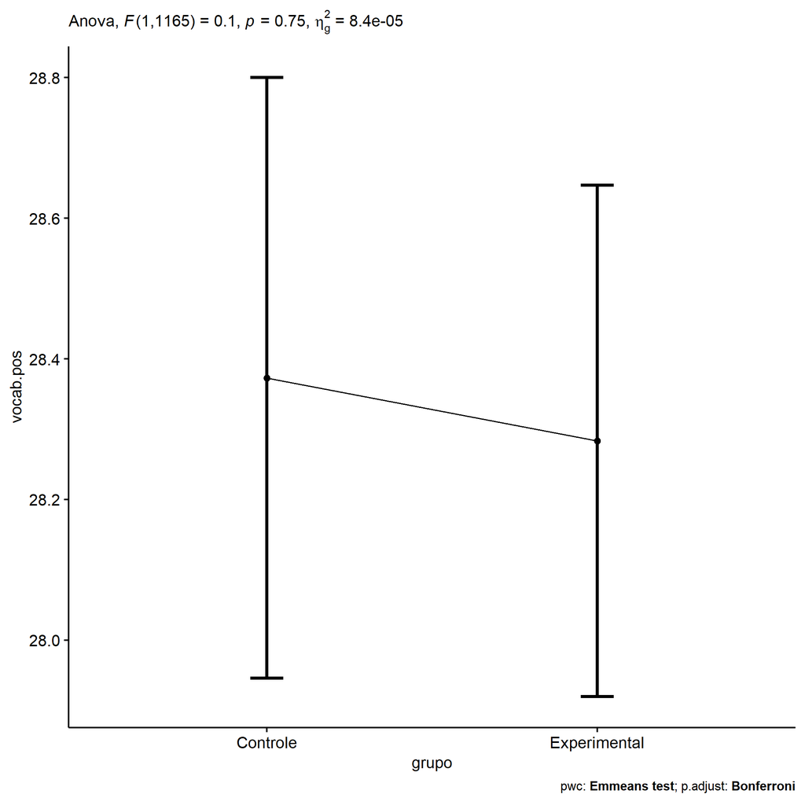

```r
if (!is.null(nrow(plots[["grupo"]]$data)))
  plots[["grupo"]] +
  if (ymin.ci < ymax.ci) ggplot2::ylim(ymin.ci, ymax.ci)
```

```r
plots <- oneWayAncovaBoxPlots(
  wdat, "vocab.pos", "grupo", aov, pwc, covar = "vocab.pre",
  theme = "classic", color = color[["grupo"]],
  subtitle = which(aov$Effect == "grupo"))
```

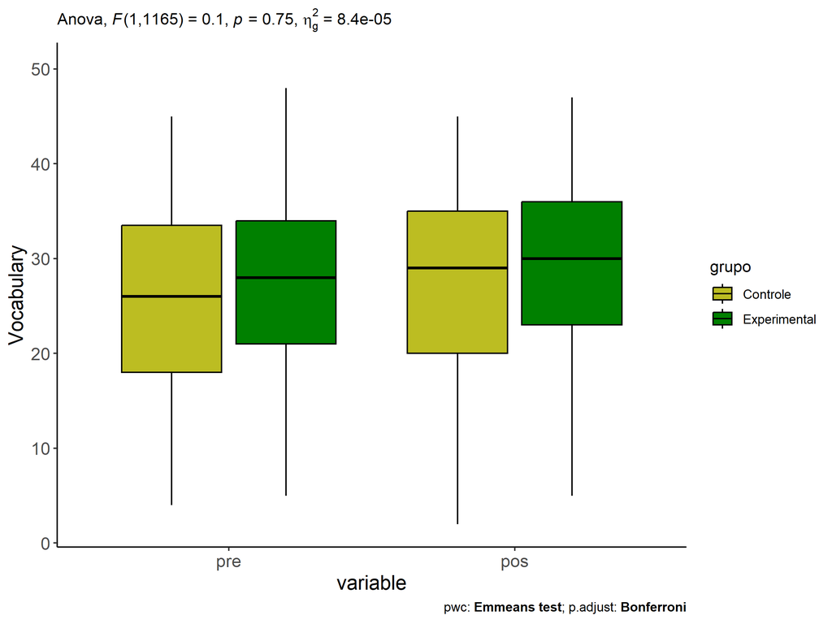

```r
if (length(unique(wdat[["grupo"]])) > 1)
  plots[["grupo"]] + ggplot2::ylab("Vocabulary") +
  ggplot2::scale_x_discrete(labels=c('pre', 'pos')) +
  if (ymin < ymax) ggplot2::ylim(ymin, ymax)
```

```r
if (length(unique(wdat.long[["grupo"]])) > 1)
  plots <- oneWayAncovaBoxPlots(
    wdat.long, "vocab", "grupo", aov, pwc.long,
    pre.post = "time", theme = "classic", color = color$prepost)
```

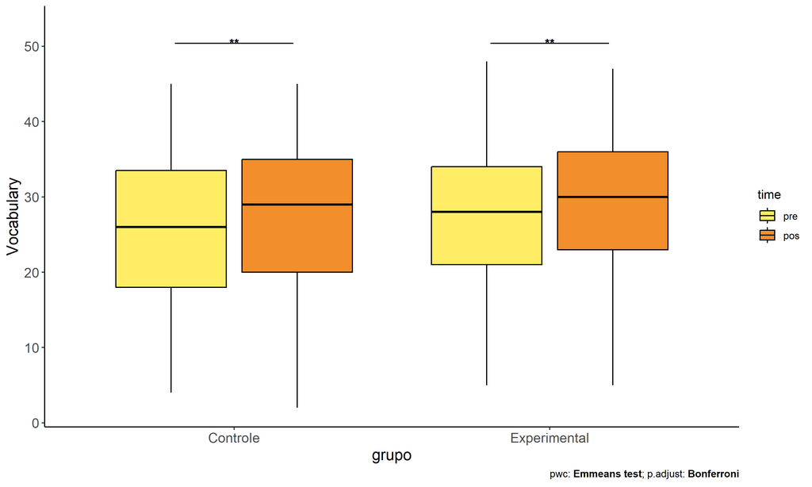

```r
if (length(unique(wdat.long[["grupo"]])) > 1)
  plots[["grupo"]] + ggplot2::ylab("Vocabulary") +
  if (ymin < ymax) ggplot2::ylim(ymin, ymax)
```

### Checking linearity assumption

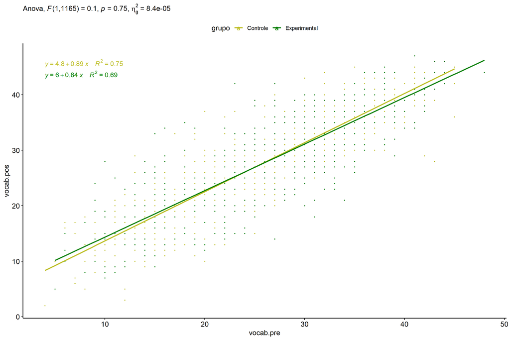

```r
ggscatter(wdat, x = "vocab.pre", y = "vocab.pos", size = 0.5,
          color = "grupo", add = "reg.line")+
  stat_regline_equation(
    aes(label =  paste(..eq.label.., ..rr.label.., sep = "~~~~"), color = grupo)
  ) +
  ggplot2::labs(subtitle = rstatix::get_test_label(aov, detailed = T, row = which(aov$Effect == "grupo"))) +
  ggplot2::scale_color_manual(values = color[["grupo"]]) +
  if (ymin < ymax) ggplot2::ylim(ymin, ymax)
```

### Checking normality and homogeneity

```r
res <- augment(lm(vocab.pos ~ vocab.pre + grupo, data = wdat))
```

```r
shapiro_test(res$.resid)
```

```
## # A tibble: 1 × 3
##   variable   statistic p.value
##   <chr>          <dbl>   <dbl>
## 1 res$.resid     0.998   0.149
```

```r
levene_test(res, .resid ~ grupo)
```

```
## # A tibble: 1 × 4
##     df1   df2 statistic     p
##   <int> <int>     <dbl> <dbl>
## 1     1  1166     0.209 0.647
```

# ANCOVA and Pairwise for two factors **grupo:Sexo**

## Without remove non-normal data

```r
pdat = remove_group_data(dat[!is.na(dat[["grupo"]]) & !is.na(dat[["Sexo"]]),],
                         "vocab.pos", c("grupo","Sexo"))
pdat = pdat[pdat[["Sexo"]] %in% do.call(
  intersect, lapply(unique(pdat[["grupo"]]), FUN = function(x) {
    unique(pdat[["Sexo"]][which(pdat[["grupo"]] == x)])
  })),]
pdat[["grupo"]] = factor(pdat[["grupo"]], level[["grupo"]])
pdat[["Sexo"]] = factor(
  pdat[["Sexo"]],
  level[["Sexo"]][level[["Sexo"]] %in% unique(pdat[["Sexo"]])])

pdat.long <- rbind(pdat[,c("id","grupo","Sexo")], pdat[,c("id","grupo","Sexo")])
pdat.long[["time"]] <- c(rep("pre", nrow(pdat)), rep("pos", nrow(pdat)))
pdat.long[["time"]] <- factor(pdat.long[["time"]], c("pre","pos"))
pdat.long[["vocab"]] <- c(pdat[["vocab.pre"]], pdat[["vocab.pos"]])

if (length(unique(pdat[["Sexo"]])) >= 2) {
  aov = anova_test(pdat, vocab.pos ~ vocab.pre + grupo*Sexo)
  laov[["grupo:Sexo"]] <- get_anova_table(aov)
}
```

```r
if (length(unique(pdat[["Sexo"]])) >= 2) {
  pwcs <- list()
  pwcs[["Sexo"]] <- emmeans_test(
    group_by(pdat, grupo), vocab.pos ~ Sexo,
    covariate = vocab.pre, p.adjust.method = "bonferroni")
  pwcs[["grupo"]] <- emmeans_test(
    group_by(pdat, Sexo), vocab.pos ~ grupo,
    covariate = vocab.pre, p.adjust.method = "bonferroni")

  pwc <- plyr::rbind.fill(pwcs[["grupo"]], pwcs[["Sexo"]])
  pwc <- pwc[,c("grupo","Sexo", colnames(pwc)[!colnames(pwc) %in% c("grupo","Sexo")])]
}
```

```r
if (length(unique(pdat[["Sexo"]])) >= 2) {
  pwc.long <- emmeans_test(dplyr::group_by_at(pdat.long, c("grupo","Sexo")),
                           vocab ~ time,
                           p.adjust.method = "bonferroni")
  lpwc[["grupo:Sexo"]] <- plyr::rbind.fill(pwc, pwc.long)
}
```

```r
if (length(unique(pdat[["Sexo"]])) >= 2) {
  ds <- get.descriptives(pdat, "vocab.pos", c("grupo","Sexo"), covar = "vocab.pre")
  ds <- merge(ds[ds$variable != "vocab.pre",],
              ds[ds$variable == "vocab.pre", !colnames(ds) %in% c("variable")],
              by = c("grupo","Sexo"), all.x = T, suffixes = c("", ".vocab.pre"))
  ds <- merge(get_emmeans(pwcs[["grupo"]]), ds,
              by = c("grupo","Sexo"), suffixes = c(".emms", ""))
  ds <- ds[,c("grupo","Sexo","n","mean.vocab.pre","se.vocab.pre","mean","se",
              "emmean","se.emms","conf.low","conf.high")]

  colnames(ds) <- c("grupo","Sexo", "N", paste0(c("M","SE")," (pre)"),
                    paste0(c("M","SE"), " (unadj)"),
                    paste0(c("M", "SE"), " (adj)"), "conf.low", "conf.high")

  lemms[["grupo:Sexo"]] <- ds
}
```

## Computing ANCOVA and PairWise After removing non-normal data (OK)

```r
if (length(unique(pdat[["Sexo"]])) >= 2) {
  wdat = pdat

  res = residuals(lm(vocab.pos ~ vocab.pre + grupo*Sexo, data = wdat))
  non.normal = getNonNormal(res, wdat$id, plimit = 0.05)

  wdat = wdat[!wdat$id %in% non.normal,]

  wdat.long <- rbind(wdat[,c("id","grupo","Sexo")], wdat[,c("id","grupo","Sexo")])
  wdat.long[["time"]] <- c(rep("pre", nrow(wdat)), rep("pos", nrow(wdat)))
  wdat.long[["time"]] <- factor(wdat.long[["time"]], c("pre","pos"))
  wdat.long[["vocab"]] <- c(wdat[["vocab.pre"]], wdat[["vocab.pos"]])


  ldat[["grupo:Sexo"]] = wdat

  (non.normal)
}
```

```
##  [1] "P1113" "P1003" "P1139" "P983"  "P852"  "P2232" "P2207" "P1966" "P2192" "P2304" "P1129"
## [12] "P1056" "P1069" "P2245" "P3260" "P3473" "P887"  "P1961" "P2251" "P888"  "P976"  "P2853"
## [23] "P1006" "P1936" "P3654" "P3042" "P996"  "P1865" "P3265" "P1012" "P1620" "P2957" "P2176"
## [34] "P2850" "P2458" "P1831" "P478"  "P916"  "P913"  "P489"  "P1112" "P3106" "P1790" "P3499"
## [45] "P3548" "P2219" "P2856" "P863"  "P1781" "P1066" "P842"  "P1151" "P3580" "P3228" "P1126"
## [56] "P837"  "P476"  "P2004" "P2339" "P2098"
```

```r
if (length(unique(pdat[["Sexo"]])) >= 2) {
  aov = anova_test(wdat, vocab.pos ~ vocab.pre + grupo*Sexo)
  laov[["grupo:Sexo"]] <- merge(get_anova_table(aov), laov[["grupo:Sexo"]],
                                         by="Effect", suffixes = c("","'"))
  df = get_anova_table(aov)
}
```

| Effect | DFn | DFd | F | p | p<.05 | ges |
| --- | --- | --- | --- | --- | --- | --- |
| vocab.pre | 1 | 1165 | 2910.637 | 0.000 | * | 0.714 |
| grupo | 1 | 1165 | 0.107 | 0.743 |  | 0.000 |
| Sexo | 1 | 1165 | 24.154 | 0.000 | * | 0.020 |
| grupo:Sexo | 1 | 1165 | 0.849 | 0.357 |  | 0.001 |

```r
if (length(unique(pdat[["Sexo"]])) >= 2) {
  pwcs <- list()
  pwcs[["Sexo"]] <- emmeans_test(
    group_by(wdat, grupo), vocab.pos ~ Sexo,
    covariate = vocab.pre, p.adjust.method = "bonferroni")
  pwcs[["grupo"]] <- emmeans_test(
    group_by(wdat, Sexo), vocab.pos ~ grupo,
    covariate = vocab.pre, p.adjust.method = "bonferroni")

  pwc <- plyr::rbind.fill(pwcs[["grupo"]], pwcs[["Sexo"]])
  pwc <- pwc[,c("grupo","Sexo", colnames(pwc)[!colnames(pwc) %in% c("grupo","Sexo")])]
}
```

| grupo | Sexo | term | .y. | group1 | group2 | df | statistic | p | p.adj | p.adj.signif |
| --- | --- | --- | --- | --- | --- | --- | --- | --- | --- | --- |
|  | F | vocab.pre*grupo | vocab.pos | Controle | Experimental | 1165 | -0.406 | 0.685 | 0.685 | ns |
|  | M | vocab.pre*grupo | vocab.pos | Controle | Experimental | 1165 | 0.888 | 0.375 | 0.375 | ns |
| Controle |  | vocab.pre*Sexo | vocab.pos | F | M | 1165 | 2.490 | 0.013 | 0.013 | * |
| Experimental |  | vocab.pre*Sexo | vocab.pos | F | M | 1165 | 4.342 | 0.000 | 0.000 | **** |

```r
if (length(unique(pdat[["Sexo"]])) >= 2) {
  pwc.long <- emmeans_test(dplyr::group_by_at(wdat.long, c("grupo","Sexo")),
                           vocab ~ time,
                           p.adjust.method = "bonferroni")
  lpwc[["grupo:Sexo"]] <- merge(plyr::rbind.fill(pwc, pwc.long),
                                         lpwc[["grupo:Sexo"]],
                                         by=c("grupo","Sexo","term",".y.","group1","group2"),
                                         suffixes = c("","'"))
}
```

| grupo | Sexo | term | .y. | group1 | group2 | df | statistic | p | p.adj | p.adj.signif |
| --- | --- | --- | --- | --- | --- | --- | --- | --- | --- | --- |
| Controle | F | time | vocab | pre | pos | 2332 | -2.681 | 0.007 | 0.007 | ** |
| Controle | M | time | vocab | pre | pos | 2332 | -1.731 | 0.084 | 0.084 | ns |
| Experimental | F | time | vocab | pre | pos | 2332 | -3.232 | 0.001 | 0.001 | ** |
| Experimental | M | time | vocab | pre | pos | 2332 | -0.971 | 0.332 | 0.332 | ns |

```r
if (length(unique(pdat[["Sexo"]])) >= 2) {
  ds <- get.descriptives(wdat, "vocab.pos", c("grupo","Sexo"), covar = "vocab.pre")
  ds <- merge(ds[ds$variable != "vocab.pre",],
              ds[ds$variable == "vocab.pre", !colnames(ds) %in% c("variable")],
              by = c("grupo","Sexo"), all.x = T, suffixes = c("", ".vocab.pre"))
  ds <- merge(get_emmeans(pwcs[["grupo"]]), ds,
              by = c("grupo","Sexo"), suffixes = c(".emms", ""))
  ds <- ds[,c("grupo","Sexo","n","mean.vocab.pre","se.vocab.pre",
              "mean","se","emmean","se.emms","conf.low","conf.high")]

  colnames(ds) <- c("grupo","Sexo", "N", paste0(c("M","SE")," (pre)"),
                    paste0(c("M","SE"), " (unadj)"),
                    paste0(c("M", "SE"), " (adj)"), "conf.low", "conf.high")

  lemms[["grupo:Sexo"]] <- merge(ds, lemms[["grupo:Sexo"]],
                                          by=c("grupo","Sexo"), suffixes = c("","'"))
}
```

| grupo | Sexo | N | M (pre) | SE (pre) | M (unadj) | SE (unadj) | M (adj) | SE (adj) | conf.low | conf.high |
| --- | --- | --- | --- | --- | --- | --- | --- | --- | --- | --- |
| Controle | F | 249 | 26.815 | 0.549 | 28.964 | 0.539 | 28.841 | 0.304 | 28.245 | 29.438 |
| Controle | M | 244 | 24.615 | 0.628 | 26.016 | 0.659 | 27.762 | 0.309 | 27.157 | 28.368 |
| Experimental | F | 353 | 27.705 | 0.463 | 29.881 | 0.442 | 29.003 | 0.256 | 28.501 | 29.504 |
| Experimental | M | 324 | 26.981 | 0.480 | 27.664 | 0.496 | 27.400 | 0.266 | 26.877 | 27.923 |

### Plots for ancova

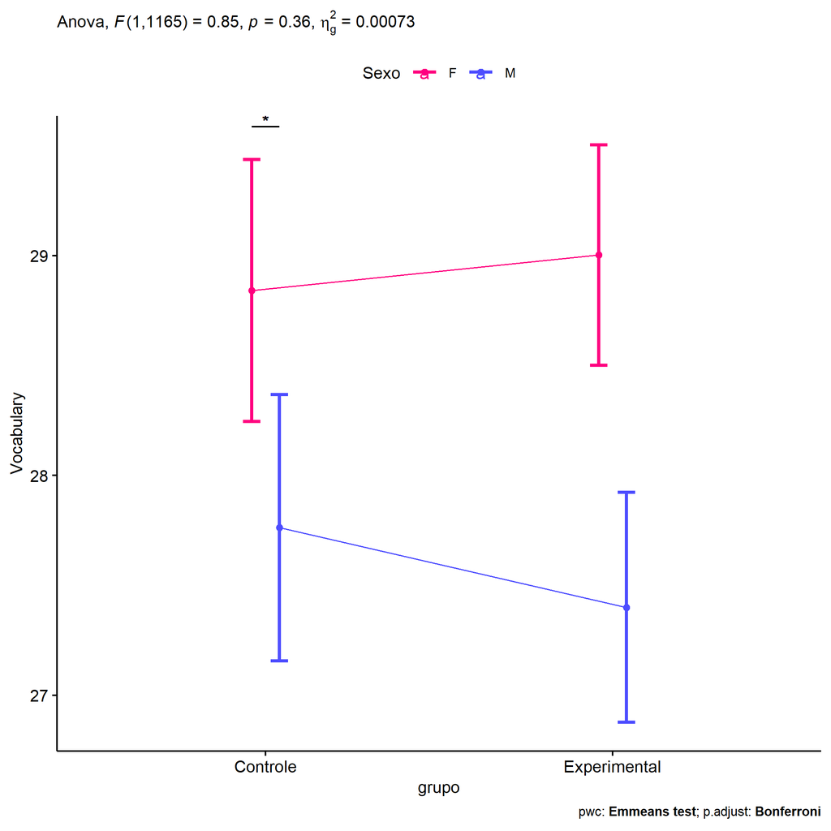

```r
if (length(unique(pdat[["Sexo"]])) >= 2) {
  ggPlotAoC2(pwcs, "grupo", "Sexo", aov, ylab = "Vocabulary",
             subtitle = which(aov$Effect == "grupo:Sexo"), addParam = "errorbar") +
    ggplot2::scale_color_manual(values = color[["Sexo"]]) +
    if (ymin.ci < ymax.ci) ggplot2::ylim(ymin.ci, ymax.ci)
}
```

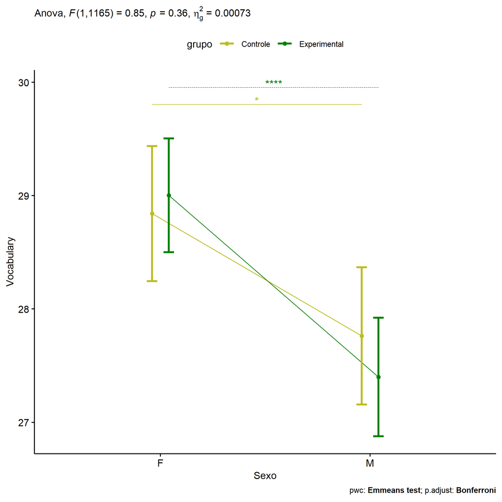

```r
if (length(unique(pdat[["Sexo"]])) >= 2) {
  ggPlotAoC2(pwcs, "Sexo", "grupo", aov, ylab = "Vocabulary",
               subtitle = which(aov$Effect == "grupo:Sexo"), addParam = "errorbar") +
      ggplot2::scale_color_manual(values = color[["grupo"]]) +
      if (ymin.ci < ymax.ci) ggplot2::ylim(ymin.ci, ymax.ci)
}
```

```r
if (length(unique(pdat[["Sexo"]])) >= 2) {
  plots <- twoWayAncovaBoxPlots(
    wdat, "vocab.pos", c("grupo","Sexo"), aov, pwcs, covar = "vocab.pre",
    theme = "classic", color = color[["grupo:Sexo"]],
    subtitle = which(aov$Effect == "grupo:Sexo"))
}
```

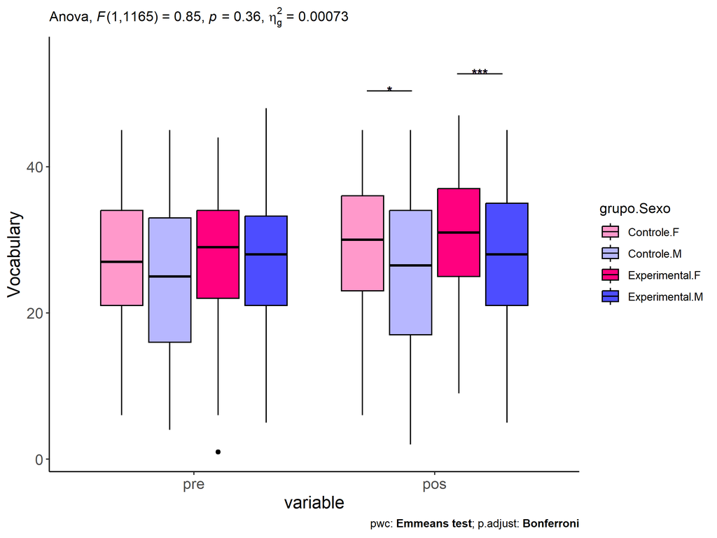

```r
if (length(unique(pdat[["Sexo"]])) >= 2) {
  plots[["grupo:Sexo"]] + ggplot2::ylab("Vocabulary") +
  ggplot2::scale_x_discrete(labels=c('pre', 'pos')) +
  if (ymin < ymax) ggplot2::ylim(ymin, ymax)
}
```

```r
if (length(unique(pdat[["Sexo"]])) >= 2) {
  plots <- twoWayAncovaBoxPlots(
    wdat.long, "vocab", c("grupo","Sexo"), aov, pwc.long,
    pre.post = "time",
    theme = "classic", color = color$prepost)
}
```

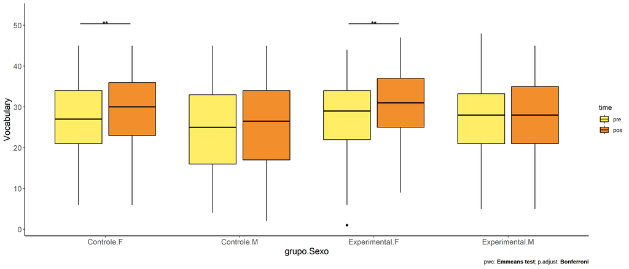

```r
if (length(unique(pdat[["Sexo"]])) >= 2)
  plots[["grupo:Sexo"]] + ggplot2::ylab("Vocabulary") +
    if (ymin < ymax) ggplot2::ylim(ymin, ymax)
```

### Checking linearity assumption

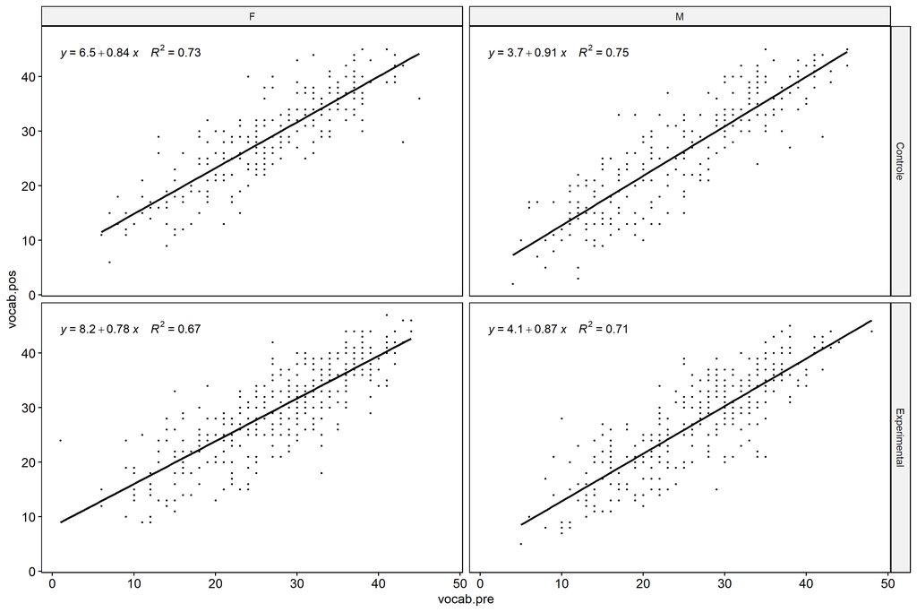

```r
if (length(unique(pdat[["Sexo"]])) >= 2) {
  ggscatter(wdat, x = "vocab.pre", y = "vocab.pos", size = 0.5,
            facet.by = c("grupo","Sexo"), add = "reg.line")+
    stat_regline_equation(
      aes(label =  paste(..eq.label.., ..rr.label.., sep = "~~~~"))
    ) +
    if (ymin < ymax) ggplot2::ylim(ymin, ymax)
}
```

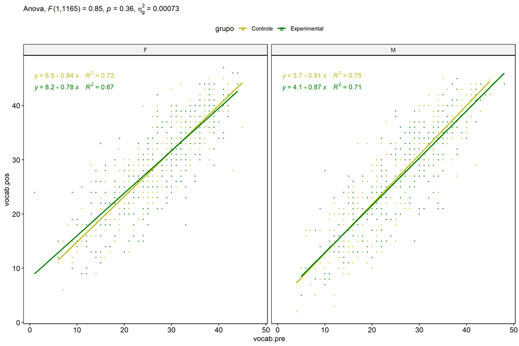

```r
if (length(unique(pdat[["Sexo"]])) >= 2) {
  ggscatter(wdat, x = "vocab.pre", y = "vocab.pos", size = 0.5,
            color = "grupo", facet.by = "Sexo", add = "reg.line")+
    stat_regline_equation(
      aes(label =  paste(..eq.label.., ..rr.label.., sep = "~~~~"), color = grupo)
    ) +
    ggplot2::labs(subtitle = rstatix::get_test_label(aov, detailed = T, row = which(aov$Effect == "grupo:Sexo"))) +
    ggplot2::scale_color_manual(values = color[["grupo"]]) +
    if (ymin < ymax) ggplot2::ylim(ymin, ymax)
}
```

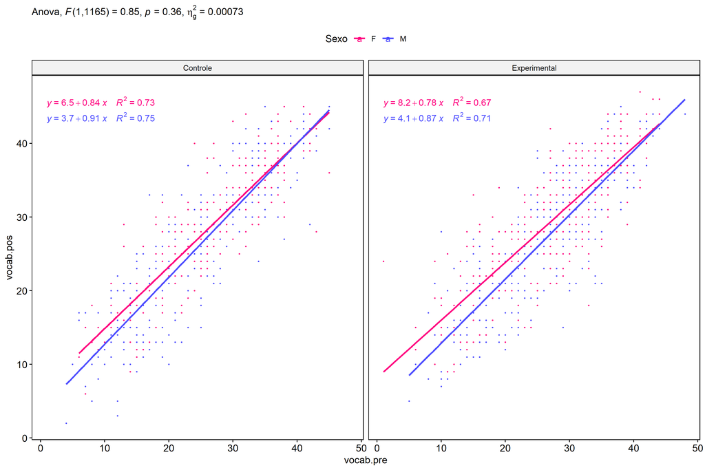

```r
if (length(unique(pdat[["Sexo"]])) >= 2) {
  ggscatter(wdat, x = "vocab.pre", y = "vocab.pos", size = 0.5,
            color = "Sexo", facet.by = "grupo", add = "reg.line")+
    stat_regline_equation(
      aes(label =  paste(..eq.label.., ..rr.label.., sep = "~~~~"), color = Sexo)
    ) +
    ggplot2::labs(subtitle = rstatix::get_test_label(aov, detailed = T, row = which(aov$Effect == "grupo:Sexo"))) +
    ggplot2::scale_color_manual(values = color[["Sexo"]]) +
    if (ymin < ymax) ggplot2::ylim(ymin, ymax)
}
```

### Checking normality and homogeneity

```r
if (length(unique(pdat[["Sexo"]])) >= 2)
  res <- augment(lm(vocab.pos ~ vocab.pre + grupo*Sexo, data = wdat))
```

```r
if (length(unique(pdat[["Sexo"]])) >= 2)
  shapiro_test(res$.resid)
```

```
## # A tibble: 1 × 3
##   variable   statistic p.value
##   <chr>          <dbl>   <dbl>
## 1 res$.resid     0.998   0.224
```

```r
if (length(unique(pdat[["Sexo"]])) >= 2)
  levene_test(res, .resid ~ grupo*Sexo)
```

```
## # A tibble: 1 × 4
##     df1   df2 statistic      p
##   <int> <int>     <dbl>  <dbl>
## 1     3  1166      2.55 0.0540
```

# ANCOVA and Pairwise for two factors **grupo:Zona**

## Without remove non-normal data

```r
pdat = remove_group_data(dat[!is.na(dat[["grupo"]]) & !is.na(dat[["Zona"]]),],
                         "vocab.pos", c("grupo","Zona"))
pdat = pdat[pdat[["Zona"]] %in% do.call(
  intersect, lapply(unique(pdat[["grupo"]]), FUN = function(x) {
    unique(pdat[["Zona"]][which(pdat[["grupo"]] == x)])
  })),]
pdat[["grupo"]] = factor(pdat[["grupo"]], level[["grupo"]])
pdat[["Zona"]] = factor(
  pdat[["Zona"]],
  level[["Zona"]][level[["Zona"]] %in% unique(pdat[["Zona"]])])

pdat.long <- rbind(pdat[,c("id","grupo","Zona")], pdat[,c("id","grupo","Zona")])
pdat.long[["time"]] <- c(rep("pre", nrow(pdat)), rep("pos", nrow(pdat)))
pdat.long[["time"]] <- factor(pdat.long[["time"]], c("pre","pos"))
pdat.long[["vocab"]] <- c(pdat[["vocab.pre"]], pdat[["vocab.pos"]])

if (length(unique(pdat[["Zona"]])) >= 2) {
  aov = anova_test(pdat, vocab.pos ~ vocab.pre + grupo*Zona)
  laov[["grupo:Zona"]] <- get_anova_table(aov)
}
```

```r
if (length(unique(pdat[["Zona"]])) >= 2) {
  pwcs <- list()
  pwcs[["Zona"]] <- emmeans_test(
    group_by(pdat, grupo), vocab.pos ~ Zona,
    covariate = vocab.pre, p.adjust.method = "bonferroni")
  pwcs[["grupo"]] <- emmeans_test(
    group_by(pdat, Zona), vocab.pos ~ grupo,
    covariate = vocab.pre, p.adjust.method = "bonferroni")

  pwc <- plyr::rbind.fill(pwcs[["grupo"]], pwcs[["Zona"]])
  pwc <- pwc[,c("grupo","Zona", colnames(pwc)[!colnames(pwc) %in% c("grupo","Zona")])]
}
```

```r
if (length(unique(pdat[["Zona"]])) >= 2) {
  pwc.long <- emmeans_test(dplyr::group_by_at(pdat.long, c("grupo","Zona")),
                           vocab ~ time,
                           p.adjust.method = "bonferroni")
  lpwc[["grupo:Zona"]] <- plyr::rbind.fill(pwc, pwc.long)
}
```

```r
if (length(unique(pdat[["Zona"]])) >= 2) {
  ds <- get.descriptives(pdat, "vocab.pos", c("grupo","Zona"), covar = "vocab.pre")
  ds <- merge(ds[ds$variable != "vocab.pre",],
              ds[ds$variable == "vocab.pre", !colnames(ds) %in% c("variable")],
              by = c("grupo","Zona"), all.x = T, suffixes = c("", ".vocab.pre"))
  ds <- merge(get_emmeans(pwcs[["grupo"]]), ds,
              by = c("grupo","Zona"), suffixes = c(".emms", ""))
  ds <- ds[,c("grupo","Zona","n","mean.vocab.pre","se.vocab.pre","mean","se",
              "emmean","se.emms","conf.low","conf.high")]

  colnames(ds) <- c("grupo","Zona", "N", paste0(c("M","SE")," (pre)"),
                    paste0(c("M","SE"), " (unadj)"),
                    paste0(c("M", "SE"), " (adj)"), "conf.low", "conf.high")

  lemms[["grupo:Zona"]] <- ds
}
```

## Computing ANCOVA and PairWise After removing non-normal data (OK)

```r
if (length(unique(pdat[["Zona"]])) >= 2) {
  wdat = pdat

  res = residuals(lm(vocab.pos ~ vocab.pre + grupo*Zona, data = wdat))
  non.normal = getNonNormal(res, wdat$id, plimit = 0.05)

  wdat = wdat[!wdat$id %in% non.normal,]

  wdat.long <- rbind(wdat[,c("id","grupo","Zona")], wdat[,c("id","grupo","Zona")])
  wdat.long[["time"]] <- c(rep("pre", nrow(wdat)), rep("pos", nrow(wdat)))
  wdat.long[["time"]] <- factor(wdat.long[["time"]], c("pre","pos"))
  wdat.long[["vocab"]] <- c(wdat[["vocab.pre"]], wdat[["vocab.pos"]])


  ldat[["grupo:Zona"]] = wdat

  (non.normal)
}
```

```
##  [1] "P1139" "P983"  "P852"  "P2207" "P1056" "P1966" "P3260" "P2304" "P2957" "P887"  "P976"
## [12] "P3042" "P3654" "P489"  "P863"  "P2861" "P3499" "P1961" "P1831" "P478"  "P2850" "P888"
## [23] "P1012"
```

```r
if (length(unique(pdat[["Zona"]])) >= 2) {
  aov = anova_test(wdat, vocab.pos ~ vocab.pre + grupo*Zona)
  laov[["grupo:Zona"]] <- merge(get_anova_table(aov), laov[["grupo:Zona"]],
                                         by="Effect", suffixes = c("","'"))
  df = get_anova_table(aov)
}
```

| Effect | DFn | DFd | F | p | p<.05 | ges |
| --- | --- | --- | --- | --- | --- | --- |
| vocab.pre | 1 | 823 | 1893.948 | 0.000 | * | 0.697 |
| grupo | 1 | 823 | 0.821 | 0.365 |  | 0.001 |
| Zona | 1 | 823 | 0.001 | 0.979 |  | 0.000 |
| grupo:Zona | 1 | 823 | 1.291 | 0.256 |  | 0.002 |

```r
if (length(unique(pdat[["Zona"]])) >= 2) {
  pwcs <- list()
  pwcs[["Zona"]] <- emmeans_test(
    group_by(wdat, grupo), vocab.pos ~ Zona,
    covariate = vocab.pre, p.adjust.method = "bonferroni")
  pwcs[["grupo"]] <- emmeans_test(
    group_by(wdat, Zona), vocab.pos ~ grupo,
    covariate = vocab.pre, p.adjust.method = "bonferroni")

  pwc <- plyr::rbind.fill(pwcs[["grupo"]], pwcs[["Zona"]])
  pwc <- pwc[,c("grupo","Zona", colnames(pwc)[!colnames(pwc) %in% c("grupo","Zona")])]
}
```

| grupo | Zona | term | .y. | group1 | group2 | df | statistic | p | p.adj | p.adj.signif |
| --- | --- | --- | --- | --- | --- | --- | --- | --- | --- | --- |
|  | Rural | vocab.pre*grupo | vocab.pos | Controle | Experimental | 823 | 1.401 | 0.162 | 0.162 | ns |
|  | Urbana | vocab.pre*grupo | vocab.pos | Controle | Experimental | 823 | -0.384 | 0.701 | 0.701 | ns |
| Controle |  | vocab.pre*Zona | vocab.pos | Rural | Urbana | 823 | 0.858 | 0.391 | 0.391 | ns |
| Experimental |  | vocab.pre*Zona | vocab.pos | Rural | Urbana | 823 | -0.743 | 0.458 | 0.458 | ns |

```r
if (length(unique(pdat[["Zona"]])) >= 2) {
  pwc.long <- emmeans_test(dplyr::group_by_at(wdat.long, c("grupo","Zona")),
                           vocab ~ time,
                           p.adjust.method = "bonferroni")
  lpwc[["grupo:Zona"]] <- merge(plyr::rbind.fill(pwc, pwc.long),
                                         lpwc[["grupo:Zona"]],
                                         by=c("grupo","Zona","term",".y.","group1","group2"),
                                         suffixes = c("","'"))
}
```

| grupo | Zona | term | .y. | group1 | group2 | df | statistic | p | p.adj | p.adj.signif |
| --- | --- | --- | --- | --- | --- | --- | --- | --- | --- | --- |
| Controle | Rural | time | vocab | pre | pos | 1648 | -2.754 | 0.006 | 0.006 | ** |
| Controle | Urbana | time | vocab | pre | pos | 1648 | -1.284 | 0.199 | 0.199 | ns |
| Experimental | Rural | time | vocab | pre | pos | 1648 | -1.940 | 0.053 | 0.053 | ns |
| Experimental | Urbana | time | vocab | pre | pos | 1648 | -1.731 | 0.084 | 0.084 | ns |

```r
if (length(unique(pdat[["Zona"]])) >= 2) {
  ds <- get.descriptives(wdat, "vocab.pos", c("grupo","Zona"), covar = "vocab.pre")
  ds <- merge(ds[ds$variable != "vocab.pre",],
              ds[ds$variable == "vocab.pre", !colnames(ds) %in% c("variable")],
              by = c("grupo","Zona"), all.x = T, suffixes = c("", ".vocab.pre"))
  ds <- merge(get_emmeans(pwcs[["grupo"]]), ds,
              by = c("grupo","Zona"), suffixes = c(".emms", ""))
  ds <- ds[,c("grupo","Zona","n","mean.vocab.pre","se.vocab.pre",
              "mean","se","emmean","se.emms","conf.low","conf.high")]

  colnames(ds) <- c("grupo","Zona", "N", paste0(c("M","SE")," (pre)"),
                    paste0(c("M","SE"), " (unadj)"),
                    paste0(c("M", "SE"), " (adj)"), "conf.low", "conf.high")

  lemms[["grupo:Zona"]] <- merge(ds, lemms[["grupo:Zona"]],
                                          by=c("grupo","Zona"), suffixes = c("","'"))
}
```

| grupo | Zona | N | M (pre) | SE (pre) | M (unadj) | SE (unadj) | M (adj) | SE (adj) | conf.low | conf.high |
| --- | --- | --- | --- | --- | --- | --- | --- | --- | --- | --- |
| Controle | Rural | 246 | 25.138 | 0.552 | 27.362 | 0.620 | 28.390 | 0.321 | 27.760 | 29.020 |
| Controle | Urbana | 112 | 26.607 | 0.868 | 28.143 | 0.846 | 27.898 | 0.474 | 26.967 | 28.830 |
| Experimental | Rural | 284 | 26.278 | 0.519 | 27.736 | 0.532 | 27.776 | 0.298 | 27.192 | 28.361 |
| Experimental | Urbana | 186 | 27.796 | 0.643 | 29.403 | 0.632 | 28.129 | 0.369 | 27.404 | 28.854 |

### Plots for ancova

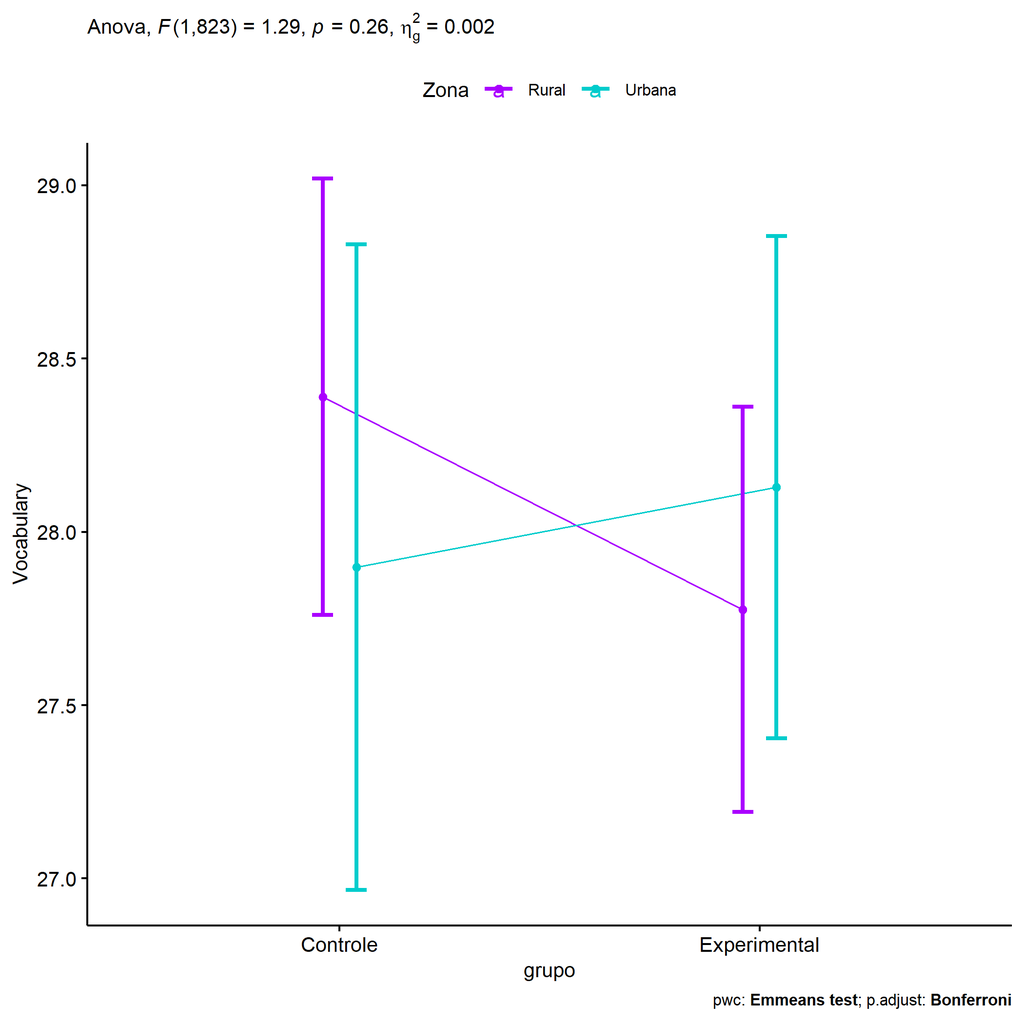

```r
if (length(unique(pdat[["Zona"]])) >= 2) {
  ggPlotAoC2(pwcs, "grupo", "Zona", aov, ylab = "Vocabulary",
             subtitle = which(aov$Effect == "grupo:Zona"), addParam = "errorbar") +
    ggplot2::scale_color_manual(values = color[["Zona"]]) +
    if (ymin.ci < ymax.ci) ggplot2::ylim(ymin.ci, ymax.ci)
}
```

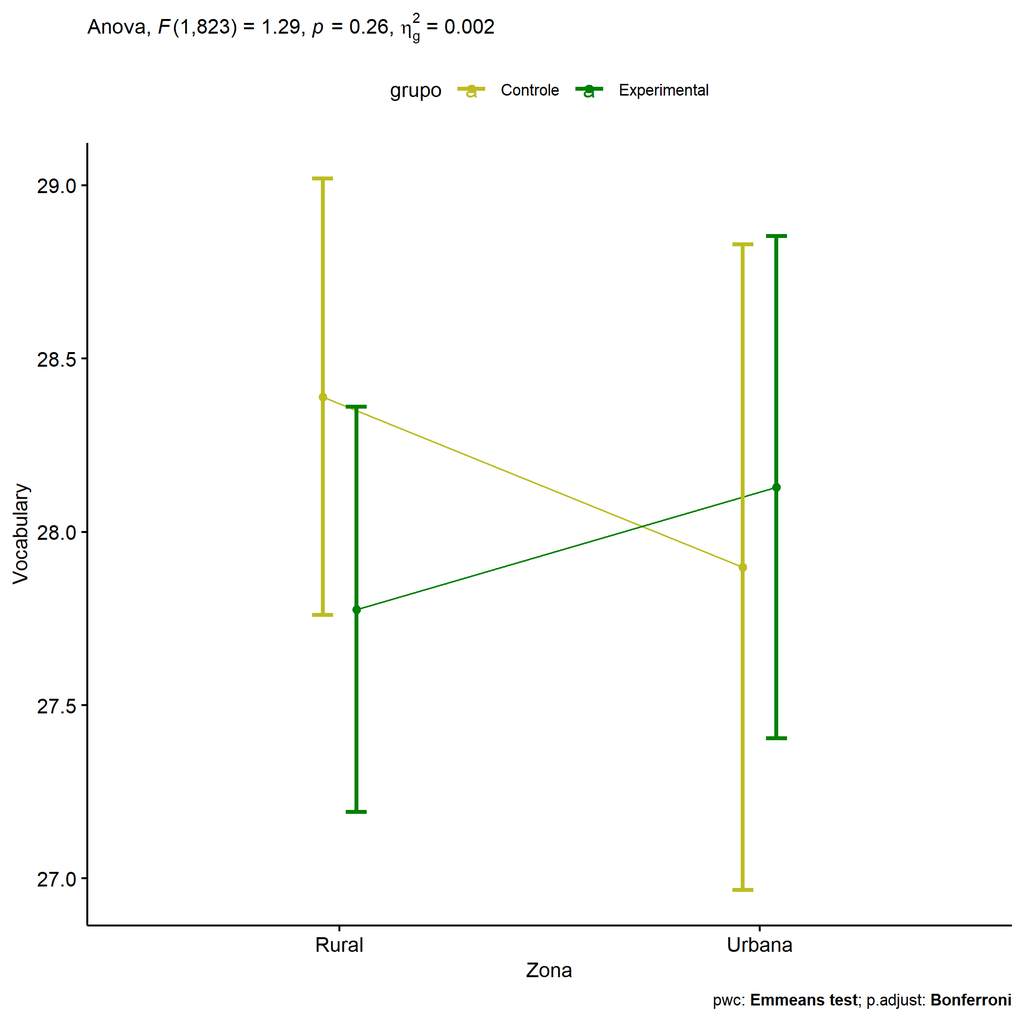

```r
if (length(unique(pdat[["Zona"]])) >= 2) {
  ggPlotAoC2(pwcs, "Zona", "grupo", aov, ylab = "Vocabulary",
               subtitle = which(aov$Effect == "grupo:Zona"), addParam = "errorbar") +
      ggplot2::scale_color_manual(values = color[["grupo"]]) +
      if (ymin.ci < ymax.ci) ggplot2::ylim(ymin.ci, ymax.ci)
}
```

```r
if (length(unique(pdat[["Zona"]])) >= 2) {
  plots <- twoWayAncovaBoxPlots(
    wdat, "vocab.pos", c("grupo","Zona"), aov, pwcs, covar = "vocab.pre",
    theme = "classic", color = color[["grupo:Zona"]],
    subtitle = which(aov$Effect == "grupo:Zona"))
}
```

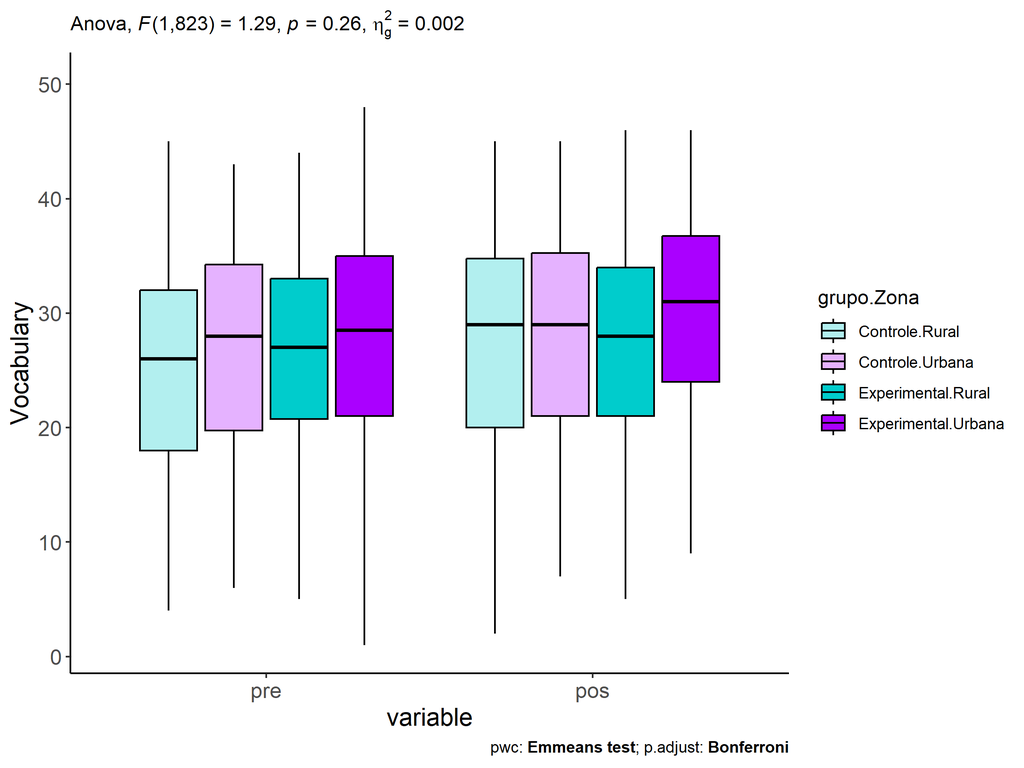

```r
if (length(unique(pdat[["Zona"]])) >= 2) {
  plots[["grupo:Zona"]] + ggplot2::ylab("Vocabulary") +
  ggplot2::scale_x_discrete(labels=c('pre', 'pos')) +
  if (ymin < ymax) ggplot2::ylim(ymin, ymax)
}
```

```r
if (length(unique(pdat[["Zona"]])) >= 2) {
  plots <- twoWayAncovaBoxPlots(
    wdat.long, "vocab", c("grupo","Zona"), aov, pwc.long,
    pre.post = "time",
    theme = "classic", color = color$prepost)
}
```

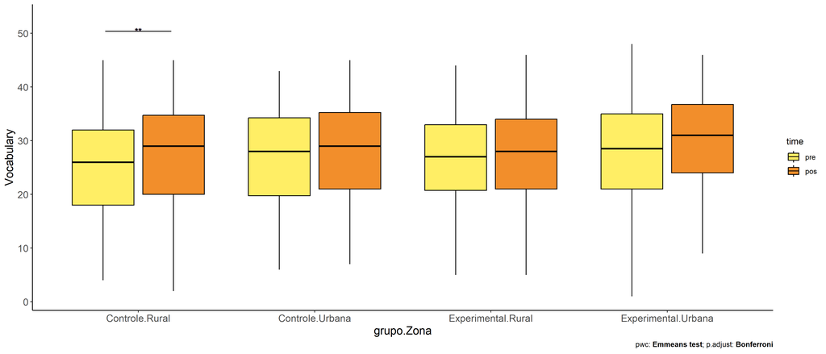

```r
if (length(unique(pdat[["Zona"]])) >= 2)
  plots[["grupo:Zona"]] + ggplot2::ylab("Vocabulary") +
    if (ymin < ymax) ggplot2::ylim(ymin, ymax)
```

### Checking linearity assumption

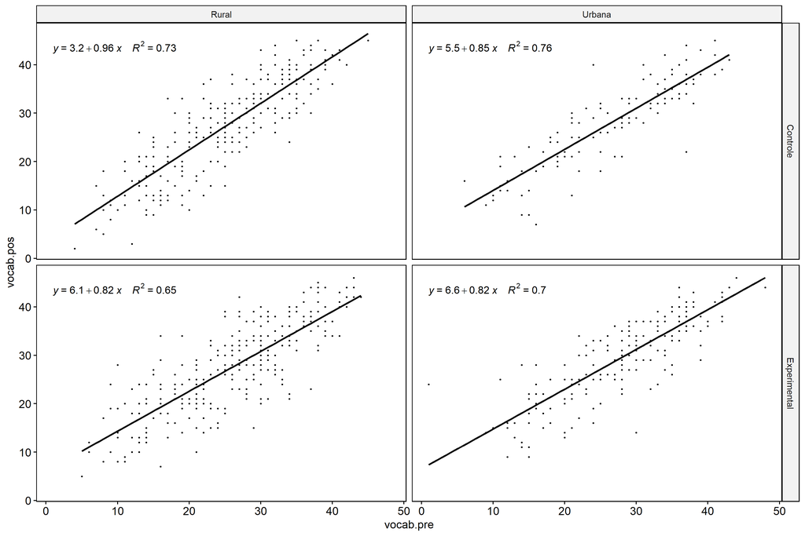

```r
if (length(unique(pdat[["Zona"]])) >= 2) {
  ggscatter(wdat, x = "vocab.pre", y = "vocab.pos", size = 0.5,
            facet.by = c("grupo","Zona"), add = "reg.line")+
    stat_regline_equation(
      aes(label =  paste(..eq.label.., ..rr.label.., sep = "~~~~"))
    ) +
    if (ymin < ymax) ggplot2::ylim(ymin, ymax)
}
```

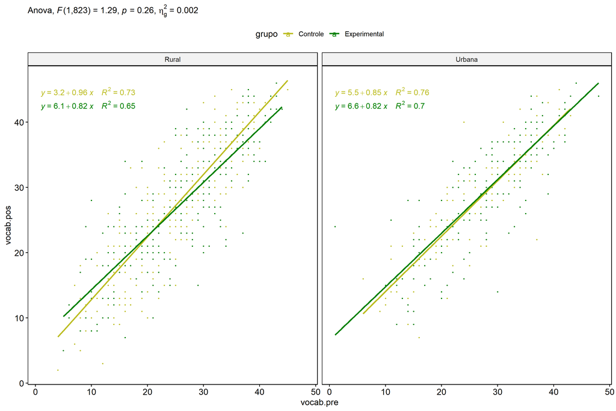

```r
if (length(unique(pdat[["Zona"]])) >= 2) {
  ggscatter(wdat, x = "vocab.pre", y = "vocab.pos", size = 0.5,
            color = "grupo", facet.by = "Zona", add = "reg.line")+
    stat_regline_equation(
      aes(label =  paste(..eq.label.., ..rr.label.., sep = "~~~~"), color = grupo)
    ) +
    ggplot2::labs(subtitle = rstatix::get_test_label(aov, detailed = T, row = which(aov$Effect == "grupo:Zona"))) +
    ggplot2::scale_color_manual(values = color[["grupo"]]) +
    if (ymin < ymax) ggplot2::ylim(ymin, ymax)
}
```

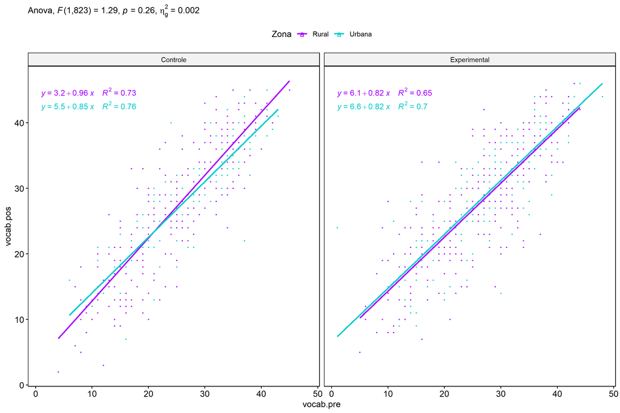

```r
if (length(unique(pdat[["Zona"]])) >= 2) {
  ggscatter(wdat, x = "vocab.pre", y = "vocab.pos", size = 0.5,
            color = "Zona", facet.by = "grupo", add = "reg.line")+
    stat_regline_equation(
      aes(label =  paste(..eq.label.., ..rr.label.., sep = "~~~~"), color = Zona)
    ) +
    ggplot2::labs(subtitle = rstatix::get_test_label(aov, detailed = T, row = which(aov$Effect == "grupo:Zona"))) +
    ggplot2::scale_color_manual(values = color[["Zona"]]) +
    if (ymin < ymax) ggplot2::ylim(ymin, ymax)
}
```

### Checking normality and homogeneity

```r
if (length(unique(pdat[["Zona"]])) >= 2)
  res <- augment(lm(vocab.pos ~ vocab.pre + grupo*Zona, data = wdat))
```

```r
if (length(unique(pdat[["Zona"]])) >= 2)
  shapiro_test(res$.resid)
```

```
## # A tibble: 1 × 3
##   variable   statistic p.value
##   <chr>          <dbl>   <dbl>
## 1 res$.resid     0.997  0.0956
```

```r
if (length(unique(pdat[["Zona"]])) >= 2)
  levene_test(res, .resid ~ grupo*Zona)
```

```
## # A tibble: 1 × 4
##     df1   df2 statistic      p
##   <int> <int>     <dbl>  <dbl>
## 1     3   824      3.51 0.0150
```

# ANCOVA and Pairwise for two factors **grupo:Cor.Raca**

## Without remove non-normal data

```r
pdat = remove_group_data(dat[!is.na(dat[["grupo"]]) & !is.na(dat[["Cor.Raca"]]),],
                         "vocab.pos", c("grupo","Cor.Raca"))
pdat = pdat[pdat[["Cor.Raca"]] %in% do.call(
  intersect, lapply(unique(pdat[["grupo"]]), FUN = function(x) {
    unique(pdat[["Cor.Raca"]][which(pdat[["grupo"]] == x)])
  })),]
pdat[["grupo"]] = factor(pdat[["grupo"]], level[["grupo"]])
pdat[["Cor.Raca"]] = factor(
  pdat[["Cor.Raca"]],
  level[["Cor.Raca"]][level[["Cor.Raca"]] %in% unique(pdat[["Cor.Raca"]])])

pdat.long <- rbind(pdat[,c("id","grupo","Cor.Raca")], pdat[,c("id","grupo","Cor.Raca")])
pdat.long[["time"]] <- c(rep("pre", nrow(pdat)), rep("pos", nrow(pdat)))
pdat.long[["time"]] <- factor(pdat.long[["time"]], c("pre","pos"))
pdat.long[["vocab"]] <- c(pdat[["vocab.pre"]], pdat[["vocab.pos"]])

if (length(unique(pdat[["Cor.Raca"]])) >= 2) {
  aov = anova_test(pdat, vocab.pos ~ vocab.pre + grupo*Cor.Raca)
  laov[["grupo:Cor.Raca"]] <- get_anova_table(aov)
}
```

```r
if (length(unique(pdat[["Cor.Raca"]])) >= 2) {
  pwcs <- list()
  pwcs[["Cor.Raca"]] <- emmeans_test(
    group_by(pdat, grupo), vocab.pos ~ Cor.Raca,
    covariate = vocab.pre, p.adjust.method = "bonferroni")
  pwcs[["grupo"]] <- emmeans_test(
    group_by(pdat, Cor.Raca), vocab.pos ~ grupo,
    covariate = vocab.pre, p.adjust.method = "bonferroni")

  pwc <- plyr::rbind.fill(pwcs[["grupo"]], pwcs[["Cor.Raca"]])
  pwc <- pwc[,c("grupo","Cor.Raca", colnames(pwc)[!colnames(pwc) %in% c("grupo","Cor.Raca")])]
}
```

```r
if (length(unique(pdat[["Cor.Raca"]])) >= 2) {
  pwc.long <- emmeans_test(dplyr::group_by_at(pdat.long, c("grupo","Cor.Raca")),
                           vocab ~ time,
                           p.adjust.method = "bonferroni")
  lpwc[["grupo:Cor.Raca"]] <- plyr::rbind.fill(pwc, pwc.long)
}
```

```r
if (length(unique(pdat[["Cor.Raca"]])) >= 2) {
  ds <- get.descriptives(pdat, "vocab.pos", c("grupo","Cor.Raca"), covar = "vocab.pre")
  ds <- merge(ds[ds$variable != "vocab.pre",],
              ds[ds$variable == "vocab.pre", !colnames(ds) %in% c("variable")],
              by = c("grupo","Cor.Raca"), all.x = T, suffixes = c("", ".vocab.pre"))
  ds <- merge(get_emmeans(pwcs[["grupo"]]), ds,
              by = c("grupo","Cor.Raca"), suffixes = c(".emms", ""))
  ds <- ds[,c("grupo","Cor.Raca","n","mean.vocab.pre","se.vocab.pre","mean","se",
              "emmean","se.emms","conf.low","conf.high")]

  colnames(ds) <- c("grupo","Cor.Raca", "N", paste0(c("M","SE")," (pre)"),
                    paste0(c("M","SE"), " (unadj)"),
                    paste0(c("M", "SE"), " (adj)"), "conf.low", "conf.high")

  lemms[["grupo:Cor.Raca"]] <- ds
}
```

## Computing ANCOVA and PairWise After removing non-normal data (OK)

```r
if (length(unique(pdat[["Cor.Raca"]])) >= 2) {
  wdat = pdat

  res = residuals(lm(vocab.pos ~ vocab.pre + grupo*Cor.Raca, data = wdat))
  non.normal = getNonNormal(res, wdat$id, plimit = 0.05)

  wdat = wdat[!wdat$id %in% non.normal,]

  wdat.long <- rbind(wdat[,c("id","grupo","Cor.Raca")], wdat[,c("id","grupo","Cor.Raca")])
  wdat.long[["time"]] <- c(rep("pre", nrow(wdat)), rep("pos", nrow(wdat)))
  wdat.long[["time"]] <- factor(wdat.long[["time"]], c("pre","pos"))
  wdat.long[["vocab"]] <- c(wdat[["vocab.pre"]], wdat[["vocab.pos"]])


  ldat[["grupo:Cor.Raca"]] = wdat

  (non.normal)
}
```

```
##  [1] "P1139" "P1003" "P1113" "P852"  "P3654" "P1056" "P1006" "P996"  "P3260" "P1069" "P850"
## [12] "P3473" "P2135" "P1112" "P913"
```

```r
if (length(unique(pdat[["Cor.Raca"]])) >= 2) {
  aov = anova_test(wdat, vocab.pos ~ vocab.pre + grupo*Cor.Raca)
  laov[["grupo:Cor.Raca"]] <- merge(get_anova_table(aov), laov[["grupo:Cor.Raca"]],
                                         by="Effect", suffixes = c("","'"))
  df = get_anova_table(aov)
}
```

| Effect | DFn | DFd | F | p | p<.05 | ges |
| --- | --- | --- | --- | --- | --- | --- |
| vocab.pre | 1 | 495 | 1060.021 | 0.000 | * | 0.682 |
| grupo | 1 | 495 | 0.240 | 0.624 |  | 0.000 |
| Cor.Raca | 2 | 495 | 2.754 | 0.065 |  | 0.011 |
| grupo:Cor.Raca | 2 | 495 | 1.448 | 0.236 |  | 0.006 |

```r
if (length(unique(pdat[["Cor.Raca"]])) >= 2) {
  pwcs <- list()
  pwcs[["Cor.Raca"]] <- emmeans_test(
    group_by(wdat, grupo), vocab.pos ~ Cor.Raca,
    covariate = vocab.pre, p.adjust.method = "bonferroni")
  pwcs[["grupo"]] <- emmeans_test(
    group_by(wdat, Cor.Raca), vocab.pos ~ grupo,
    covariate = vocab.pre, p.adjust.method = "bonferroni")

  pwc <- plyr::rbind.fill(pwcs[["grupo"]], pwcs[["Cor.Raca"]])
  pwc <- pwc[,c("grupo","Cor.Raca", colnames(pwc)[!colnames(pwc) %in% c("grupo","Cor.Raca")])]
}
```

| grupo | Cor.Raca | term | .y. | group1 | group2 | df | statistic | p | p.adj | p.adj.signif |
| --- | --- | --- | --- | --- | --- | --- | --- | --- | --- | --- |
|  | Parda | vocab.pre*grupo | vocab.pos | Controle | Experimental | 495 | -0.494 | 0.621 | 0.621 | ns |
|  | Indígena | vocab.pre*grupo | vocab.pos | Controle | Experimental | 495 | 0.611 | 0.541 | 0.541 | ns |
|  | Branca | vocab.pre*grupo | vocab.pos | Controle | Experimental | 495 | 1.584 | 0.114 | 0.114 | ns |
| Controle |  | vocab.pre*Cor.Raca | vocab.pos | Parda | Indígena | 495 | -1.442 | 0.150 | 0.450 | ns |
| Controle |  | vocab.pre*Cor.Raca | vocab.pos | Parda | Branca | 495 | -0.014 | 0.989 | 1.000 | ns |
| Controle |  | vocab.pre*Cor.Raca | vocab.pos | Indígena | Branca | 495 | 1.338 | 0.181 | 0.544 | ns |
| Experimental |  | vocab.pre*Cor.Raca | vocab.pos | Parda | Indígena | 495 | -0.568 | 0.570 | 1.000 | ns |
| Experimental |  | vocab.pre*Cor.Raca | vocab.pos | Parda | Branca | 495 | 2.342 | 0.020 | 0.059 | ns |
| Experimental |  | vocab.pre*Cor.Raca | vocab.pos | Indígena | Branca | 495 | 1.806 | 0.072 | 0.215 | ns |

```r
if (length(unique(pdat[["Cor.Raca"]])) >= 2) {
  pwc.long <- emmeans_test(dplyr::group_by_at(wdat.long, c("grupo","Cor.Raca")),
                           vocab ~ time,
                           p.adjust.method = "bonferroni")
  lpwc[["grupo:Cor.Raca"]] <- merge(plyr::rbind.fill(pwc, pwc.long),
                                         lpwc[["grupo:Cor.Raca"]],
                                         by=c("grupo","Cor.Raca","term",".y.","group1","group2"),
                                         suffixes = c("","'"))
}
```

| grupo | Cor.Raca | term | .y. | group1 | group2 | df | statistic | p | p.adj | p.adj.signif |
| --- | --- | --- | --- | --- | --- | --- | --- | --- | --- | --- |
| Controle | Parda | time | vocab | pre | pos | 992 | -1.860 | 0.063 | 0.063 | ns |
| Controle | Indígena | time | vocab | pre | pos | 992 | -1.119 | 0.263 | 0.263 | ns |
| Controle | Branca | time | vocab | pre | pos | 992 | -1.003 | 0.316 | 0.316 | ns |
| Experimental | Parda | time | vocab | pre | pos | 992 | -2.290 | 0.022 | 0.022 | * |
| Experimental | Indígena | time | vocab | pre | pos | 992 | -1.043 | 0.297 | 0.297 | ns |
| Experimental | Branca | time | vocab | pre | pos | 992 | 0.060 | 0.952 | 0.952 | ns |

```r
if (length(unique(pdat[["Cor.Raca"]])) >= 2) {
  ds <- get.descriptives(wdat, "vocab.pos", c("grupo","Cor.Raca"), covar = "vocab.pre")
  ds <- merge(ds[ds$variable != "vocab.pre",],
              ds[ds$variable == "vocab.pre", !colnames(ds) %in% c("variable")],
              by = c("grupo","Cor.Raca"), all.x = T, suffixes = c("", ".vocab.pre"))
  ds <- merge(get_emmeans(pwcs[["grupo"]]), ds,
              by = c("grupo","Cor.Raca"), suffixes = c(".emms", ""))
  ds <- ds[,c("grupo","Cor.Raca","n","mean.vocab.pre","se.vocab.pre",
              "mean","se","emmean","se.emms","conf.low","conf.high")]

  colnames(ds) <- c("grupo","Cor.Raca", "N", paste0(c("M","SE")," (pre)"),
                    paste0(c("M","SE"), " (unadj)"),
                    paste0(c("M", "SE"), " (adj)"), "conf.low", "conf.high")

  lemms[["grupo:Cor.Raca"]] <- merge(ds, lemms[["grupo:Cor.Raca"]],
                                          by=c("grupo","Cor.Raca"), suffixes = c("","'"))
}
```

| grupo | Cor.Raca | N | M (pre) | SE (pre) | M (unadj) | SE (unadj) | M (adj) | SE (adj) | conf.low | conf.high |
| --- | --- | --- | --- | --- | --- | --- | --- | --- | --- | --- |
| Controle | Branca | 54 | 26.463 | 1.129 | 28.222 | 1.247 | 27.735 | 0.727 | 26.308 | 29.163 |
| Controle | Indígena | 13 | 26.154 | 1.990 | 30.154 | 2.210 | 29.942 | 1.480 | 27.033 | 32.851 |
| Controle | Parda | 163 | 25.276 | 0.708 | 27.153 | 0.788 | 27.724 | 0.418 | 26.902 | 28.546 |
| Experimental | Branca | 60 | 28.933 | 0.997 | 28.833 | 1.286 | 26.145 | 0.694 | 24.782 | 27.509 |
| Experimental | Indígena | 18 | 22.889 | 1.854 | 26.056 | 2.012 | 28.753 | 1.261 | 26.276 | 31.230 |
| Experimental | Parda | 194 | 25.634 | 0.653 | 27.753 | 0.645 | 28.004 | 0.383 | 27.251 | 28.757 |

### Plots for ancova

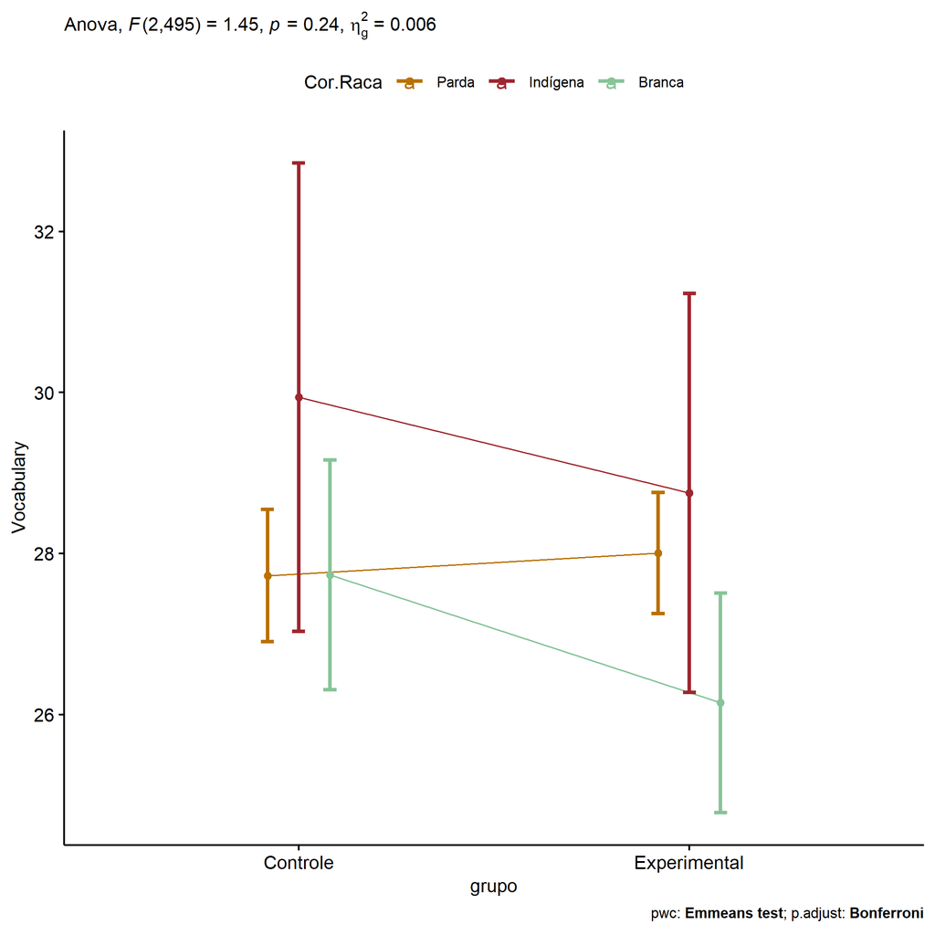

```r
if (length(unique(pdat[["Cor.Raca"]])) >= 2) {
  ggPlotAoC2(pwcs, "grupo", "Cor.Raca", aov, ylab = "Vocabulary",
             subtitle = which(aov$Effect == "grupo:Cor.Raca"), addParam = "errorbar") +
    ggplot2::scale_color_manual(values = color[["Cor.Raca"]]) +
    if (ymin.ci < ymax.ci) ggplot2::ylim(ymin.ci, ymax.ci)
}
```

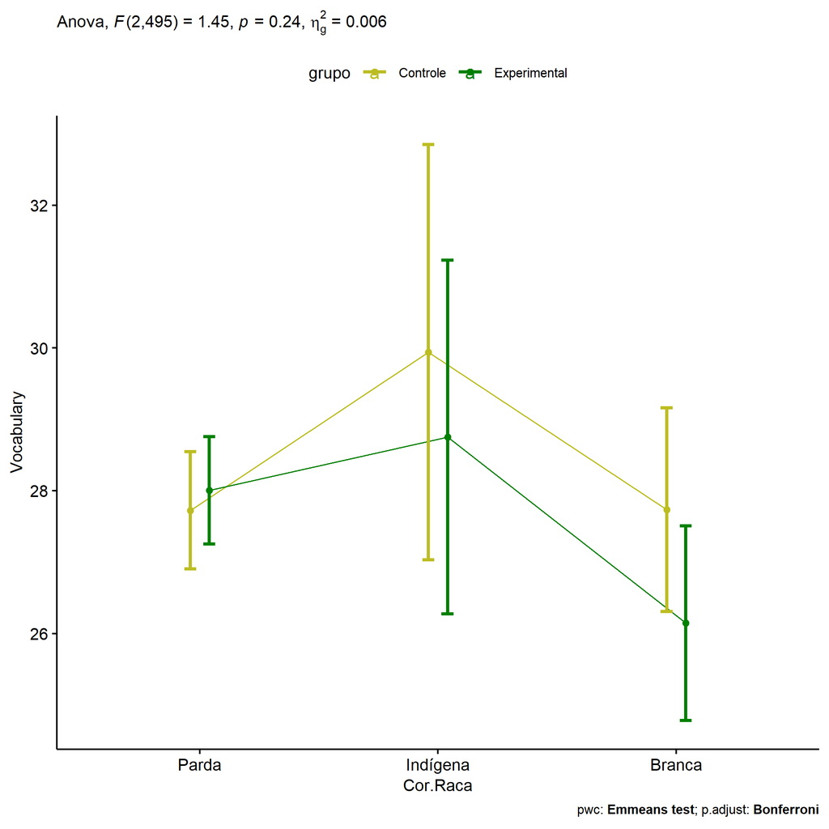

```r
if (length(unique(pdat[["Cor.Raca"]])) >= 2) {
  ggPlotAoC2(pwcs, "Cor.Raca", "grupo", aov, ylab = "Vocabulary",
               subtitle = which(aov$Effect == "grupo:Cor.Raca"), addParam = "errorbar") +
      ggplot2::scale_color_manual(values = color[["grupo"]]) +
      if (ymin.ci < ymax.ci) ggplot2::ylim(ymin.ci, ymax.ci)
}
```

```r
if (length(unique(pdat[["Cor.Raca"]])) >= 2) {
  plots <- twoWayAncovaBoxPlots(
    wdat, "vocab.pos", c("grupo","Cor.Raca"), aov, pwcs, covar = "vocab.pre",
    theme = "classic", color = color[["grupo:Cor.Raca"]],
    subtitle = which(aov$Effect == "grupo:Cor.Raca"))
}
```

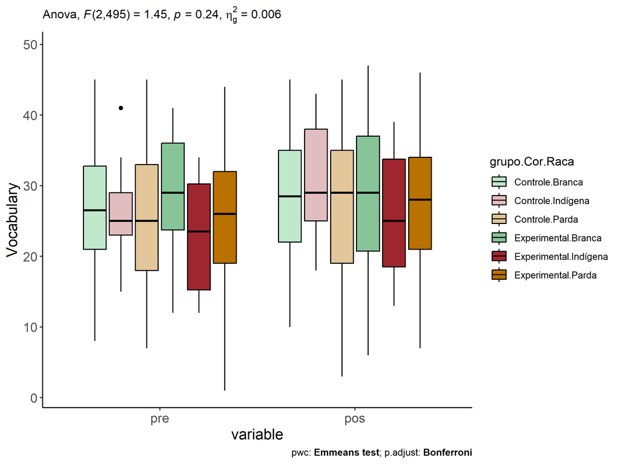

```r
if (length(unique(pdat[["Cor.Raca"]])) >= 2) {
  plots[["grupo:Cor.Raca"]] + ggplot2::ylab("Vocabulary") +
  ggplot2::scale_x_discrete(labels=c('pre', 'pos')) +
  if (ymin < ymax) ggplot2::ylim(ymin, ymax)
}
```

```r
if (length(unique(pdat[["Cor.Raca"]])) >= 2) {
  plots <- twoWayAncovaBoxPlots(
    wdat.long, "vocab", c("grupo","Cor.Raca"), aov, pwc.long,
    pre.post = "time",
    theme = "classic", color = color$prepost)
}
```

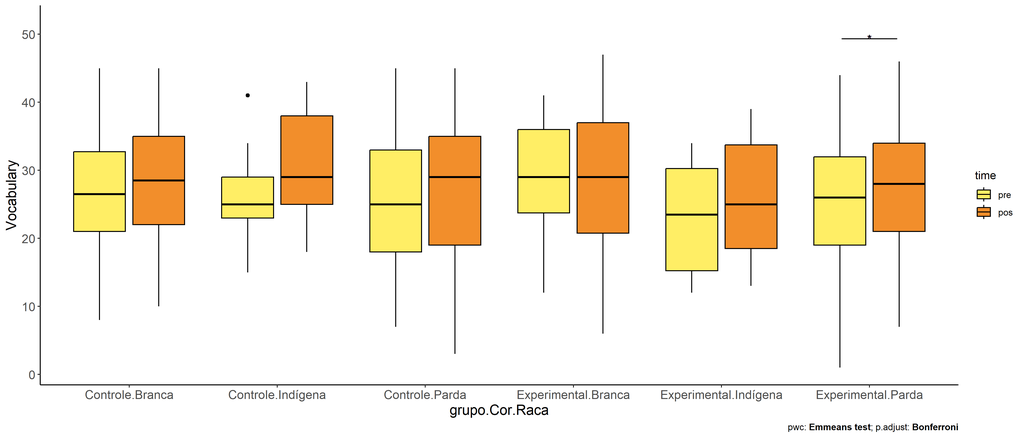

```r
if (length(unique(pdat[["Cor.Raca"]])) >= 2)
  plots[["grupo:Cor.Raca"]] + ggplot2::ylab("Vocabulary") +
    if (ymin < ymax) ggplot2::ylim(ymin, ymax)
```

### Checking linearity assumption

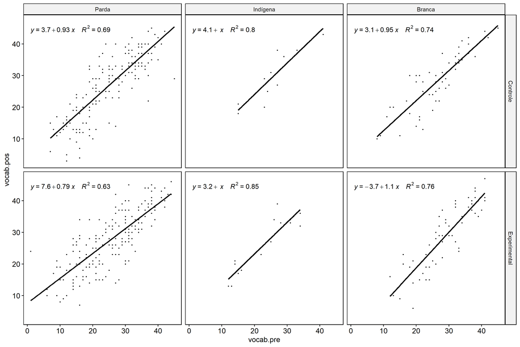

```r
if (length(unique(pdat[["Cor.Raca"]])) >= 2) {
  ggscatter(wdat, x = "vocab.pre", y = "vocab.pos", size = 0.5,
            facet.by = c("grupo","Cor.Raca"), add = "reg.line")+
    stat_regline_equation(
      aes(label =  paste(..eq.label.., ..rr.label.., sep = "~~~~"))
    ) +
    if (ymin < ymax) ggplot2::ylim(ymin, ymax)
}
```

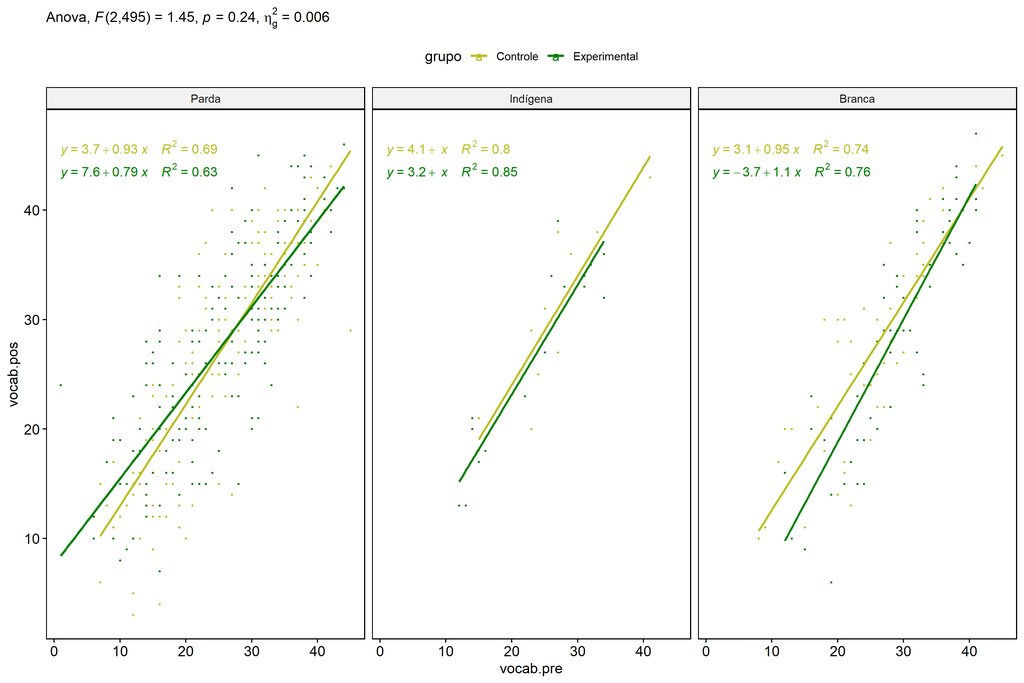

```r
if (length(unique(pdat[["Cor.Raca"]])) >= 2) {
  ggscatter(wdat, x = "vocab.pre", y = "vocab.pos", size = 0.5,
            color = "grupo", facet.by = "Cor.Raca", add = "reg.line")+
    stat_regline_equation(
      aes(label =  paste(..eq.label.., ..rr.label.., sep = "~~~~"), color = grupo)
    ) +
    ggplot2::labs(subtitle = rstatix::get_test_label(aov, detailed = T, row = which(aov$Effect == "grupo:Cor.Raca"))) +
    ggplot2::scale_color_manual(values = color[["grupo"]]) +
    if (ymin < ymax) ggplot2::ylim(ymin, ymax)
}
```

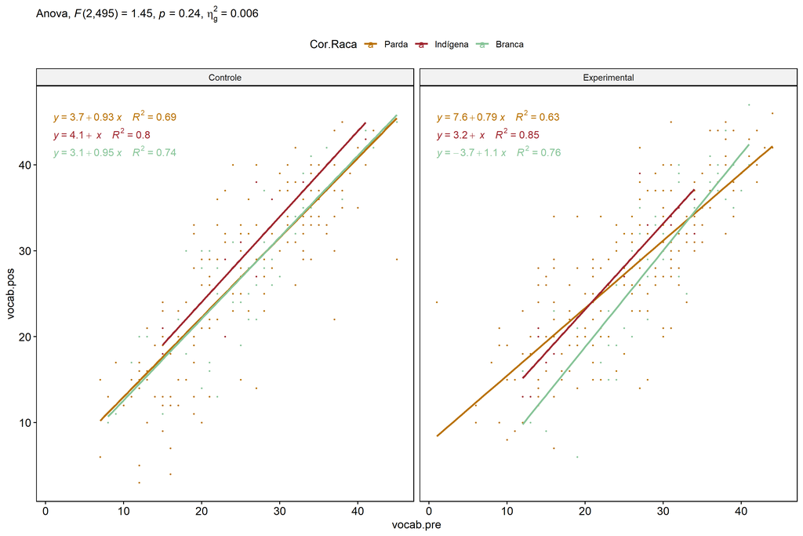

```r
if (length(unique(pdat[["Cor.Raca"]])) >= 2) {
  ggscatter(wdat, x = "vocab.pre", y = "vocab.pos", size = 0.5,
            color = "Cor.Raca", facet.by = "grupo", add = "reg.line")+
    stat_regline_equation(
      aes(label =  paste(..eq.label.., ..rr.label.., sep = "~~~~"), color = Cor.Raca)
    ) +
    ggplot2::labs(subtitle = rstatix::get_test_label(aov, detailed = T, row = which(aov$Effect == "grupo:Cor.Raca"))) +
    ggplot2::scale_color_manual(values = color[["Cor.Raca"]]) +
    if (ymin < ymax) ggplot2::ylim(ymin, ymax)
}
```

### Checking normality and homogeneity

```r
if (length(unique(pdat[["Cor.Raca"]])) >= 2)
  res <- augment(lm(vocab.pos ~ vocab.pre + grupo*Cor.Raca, data = wdat))
```

```r
if (length(unique(pdat[["Cor.Raca"]])) >= 2)
  shapiro_test(res$.resid)
```

```
## # A tibble: 1 × 3
##   variable   statistic p.value
##   <chr>          <dbl>   <dbl>
## 1 res$.resid     0.995  0.0855
```

```r
if (length(unique(pdat[["Cor.Raca"]])) >= 2)
  levene_test(res, .resid ~ grupo*Cor.Raca)
```

```
## # A tibble: 1 × 4
##     df1   df2 statistic     p
##   <int> <int>     <dbl> <dbl>
## 1     5   496      1.77 0.116
```

# ANCOVA and Pairwise for two factors **grupo:Serie**

## Without remove non-normal data

```r
pdat = remove_group_data(dat[!is.na(dat[["grupo"]]) & !is.na(dat[["Serie"]]),],
                         "vocab.pos", c("grupo","Serie"))
pdat = pdat[pdat[["Serie"]] %in% do.call(
  intersect, lapply(unique(pdat[["grupo"]]), FUN = function(x) {
    unique(pdat[["Serie"]][which(pdat[["grupo"]] == x)])
  })),]
pdat[["grupo"]] = factor(pdat[["grupo"]], level[["grupo"]])
pdat[["Serie"]] = factor(
  pdat[["Serie"]],
  level[["Serie"]][level[["Serie"]] %in% unique(pdat[["Serie"]])])

pdat.long <- rbind(pdat[,c("id","grupo","Serie")], pdat[,c("id","grupo","Serie")])
pdat.long[["time"]] <- c(rep("pre", nrow(pdat)), rep("pos", nrow(pdat)))
pdat.long[["time"]] <- factor(pdat.long[["time"]], c("pre","pos"))
pdat.long[["vocab"]] <- c(pdat[["vocab.pre"]], pdat[["vocab.pos"]])

if (length(unique(pdat[["Serie"]])) >= 2) {
  aov = anova_test(pdat, vocab.pos ~ vocab.pre + grupo*Serie)
  laov[["grupo:Serie"]] <- get_anova_table(aov)
}
```

```r
if (length(unique(pdat[["Serie"]])) >= 2) {
  pwcs <- list()
  pwcs[["Serie"]] <- emmeans_test(
    group_by(pdat, grupo), vocab.pos ~ Serie,
    covariate = vocab.pre, p.adjust.method = "bonferroni")
  pwcs[["grupo"]] <- emmeans_test(
    group_by(pdat, Serie), vocab.pos ~ grupo,
    covariate = vocab.pre, p.adjust.method = "bonferroni")

  pwc <- plyr::rbind.fill(pwcs[["grupo"]], pwcs[["Serie"]])
  pwc <- pwc[,c("grupo","Serie", colnames(pwc)[!colnames(pwc) %in% c("grupo","Serie")])]
}
```

```r
if (length(unique(pdat[["Serie"]])) >= 2) {
  pwc.long <- emmeans_test(dplyr::group_by_at(pdat.long, c("grupo","Serie")),
                           vocab ~ time,
                           p.adjust.method = "bonferroni")
  lpwc[["grupo:Serie"]] <- plyr::rbind.fill(pwc, pwc.long)
}
```

```r
if (length(unique(pdat[["Serie"]])) >= 2) {
  ds <- get.descriptives(pdat, "vocab.pos", c("grupo","Serie"), covar = "vocab.pre")
  ds <- merge(ds[ds$variable != "vocab.pre",],
              ds[ds$variable == "vocab.pre", !colnames(ds) %in% c("variable")],
              by = c("grupo","Serie"), all.x = T, suffixes = c("", ".vocab.pre"))
  ds <- merge(get_emmeans(pwcs[["grupo"]]), ds,
              by = c("grupo","Serie"), suffixes = c(".emms", ""))
  ds <- ds[,c("grupo","Serie","n","mean.vocab.pre","se.vocab.pre","mean","se",
              "emmean","se.emms","conf.low","conf.high")]

  colnames(ds) <- c("grupo","Serie", "N", paste0(c("M","SE")," (pre)"),
                    paste0(c("M","SE"), " (unadj)"),
                    paste0(c("M", "SE"), " (adj)"), "conf.low", "conf.high")

  lemms[["grupo:Serie"]] <- ds
}
```

## Computing ANCOVA and PairWise After removing non-normal data (OK)

```r
if (length(unique(pdat[["Serie"]])) >= 2) {
  wdat = pdat

  res = residuals(lm(vocab.pos ~ vocab.pre + grupo*Serie, data = wdat))
  non.normal = getNonNormal(res, wdat$id, plimit = 0.05)

  wdat = wdat[!wdat$id %in% non.normal,]

  wdat.long <- rbind(wdat[,c("id","grupo","Serie")], wdat[,c("id","grupo","Serie")])
  wdat.long[["time"]] <- c(rep("pre", nrow(wdat)), rep("pos", nrow(wdat)))
  wdat.long[["time"]] <- factor(wdat.long[["time"]], c("pre","pos"))
  wdat.long[["vocab"]] <- c(wdat[["vocab.pre"]], wdat[["vocab.pos"]])


  ldat[["grupo:Serie"]] = wdat

  (non.normal)
}
```

```
##  [1] "P1139" "P1113" "P983"  "P1003" "P2207" "P2232" "P852"  "P1056" "P2245" "P3654" "P996"
## [12] "P1069" "P2192" "P1966" "P1129" "P2304" "P1006" "P3042" "P863"  "P1961" "P3473" "P887"
## [23] "P2957" "P1112" "P1831" "P2135" "P888"  "P2206" "P3228" "P1790" "P1151" "P3265" "P1620"
## [34] "P3260" "P2251" "P489"  "P2853" "P2176" "P976"  "P2856" "P2861" "P916"  "P1936" "P837"
## [45] "P2458" "P3159" "P3499" "P842"  "P3106" "P2050" "P3097" "P491"  "P1009" "P1110" "P1057"
## [56] "P2384" "P3038" "P606"  "P3517" "P2435" "P913"  "P2219" "P2296" "P1865" "P3548" "P3635"
```

```r
if (length(unique(pdat[["Serie"]])) >= 2) {
  aov = anova_test(wdat, vocab.pos ~ vocab.pre + grupo*Serie)
  laov[["grupo:Serie"]] <- merge(get_anova_table(aov), laov[["grupo:Serie"]],
                                         by="Effect", suffixes = c("","'"))
  df = get_anova_table(aov)
}
```

| Effect | DFn | DFd | F | p | p<.05 | ges |
| --- | --- | --- | --- | --- | --- | --- |
| vocab.pre | 1 | 1155 | 2441.203 | 0.000 | * | 0.679 |
| grupo | 1 | 1155 | 0.257 | 0.613 |  | 0.000 |
| Serie | 3 | 1155 | 5.863 | 0.001 | * | 0.015 |
| grupo:Serie | 3 | 1155 | 2.341 | 0.072 |  | 0.006 |

```r
if (length(unique(pdat[["Serie"]])) >= 2) {
  pwcs <- list()
  pwcs[["Serie"]] <- emmeans_test(
    group_by(wdat, grupo), vocab.pos ~ Serie,
    covariate = vocab.pre, p.adjust.method = "bonferroni")
  pwcs[["grupo"]] <- emmeans_test(
    group_by(wdat, Serie), vocab.pos ~ grupo,
    covariate = vocab.pre, p.adjust.method = "bonferroni")

  pwc <- plyr::rbind.fill(pwcs[["grupo"]], pwcs[["Serie"]])
  pwc <- pwc[,c("grupo","Serie", colnames(pwc)[!colnames(pwc) %in% c("grupo","Serie")])]
}
```

| grupo | Serie | term | .y. | group1 | group2 | df | statistic | p | p.adj | p.adj.signif |
| --- | --- | --- | --- | --- | --- | --- | --- | --- | --- | --- |
|  | 6 ano | vocab.pre*grupo | vocab.pos | Controle | Experimental | 1155 | -1.697 | 0.090 | 0.090 | ns |
|  | 7 ano | vocab.pre*grupo | vocab.pos | Controle | Experimental | 1155 | 1.854 | 0.064 | 0.064 | ns |
|  | 8 ano | vocab.pre*grupo | vocab.pos | Controle | Experimental | 1155 | 0.962 | 0.336 | 0.336 | ns |
|  | 9 ano | vocab.pre*grupo | vocab.pos | Controle | Experimental | 1155 | -0.132 | 0.895 | 0.895 | ns |
| Controle |  | vocab.pre*Serie | vocab.pos | 6 ano | 7 ano | 1155 | -2.523 | 0.012 | 0.071 | ns |
| Controle |  | vocab.pre*Serie | vocab.pos | 6 ano | 8 ano | 1155 | -2.960 | 0.003 | 0.019 | * |
| Controle |  | vocab.pre*Serie | vocab.pos | 6 ano | 9 ano | 1155 | -3.336 | 0.001 | 0.005 | ** |
| Controle |  | vocab.pre*Serie | vocab.pos | 7 ano | 8 ano | 1155 | -0.792 | 0.428 | 1.000 | ns |
| Controle |  | vocab.pre*Serie | vocab.pos | 7 ano | 9 ano | 1155 | -1.097 | 0.273 | 1.000 | ns |
| Controle |  | vocab.pre*Serie | vocab.pos | 8 ano | 9 ano | 1155 | -0.233 | 0.816 | 1.000 | ns |
| Experimental |  | vocab.pre*Serie | vocab.pos | 6 ano | 7 ano | 1155 | 0.952 | 0.341 | 1.000 | ns |
| Experimental |  | vocab.pre*Serie | vocab.pos | 6 ano | 8 ano | 1155 | -0.728 | 0.467 | 1.000 | ns |
| Experimental |  | vocab.pre*Serie | vocab.pos | 6 ano | 9 ano | 1155 | -2.206 | 0.028 | 0.165 | ns |
| Experimental |  | vocab.pre*Serie | vocab.pos | 7 ano | 8 ano | 1155 | -1.764 | 0.078 | 0.468 | ns |
| Experimental |  | vocab.pre*Serie | vocab.pos | 7 ano | 9 ano | 1155 | -3.324 | 0.001 | 0.005 | ** |
| Experimental |  | vocab.pre*Serie | vocab.pos | 8 ano | 9 ano | 1155 | -1.595 | 0.111 | 0.667 | ns |

```r
if (length(unique(pdat[["Serie"]])) >= 2) {
  pwc.long <- emmeans_test(dplyr::group_by_at(wdat.long, c("grupo","Serie")),
                           vocab ~ time,
                           p.adjust.method = "bonferroni")
  lpwc[["grupo:Serie"]] <- merge(plyr::rbind.fill(pwc, pwc.long),
                                         lpwc[["grupo:Serie"]],
                                         by=c("grupo","Serie","term",".y.","group1","group2"),
                                         suffixes = c("","'"))
}
```

| grupo | Serie | term | .y. | group1 | group2 | df | statistic | p | p.adj | p.adj.signif |
| --- | --- | --- | --- | --- | --- | --- | --- | --- | --- | --- |
| Controle | 6 ano | time | vocab | pre | pos | 2312 | -1.446 | 0.148 | 0.148 | ns |
| Controle | 7 ano | time | vocab | pre | pos | 2312 | -2.374 | 0.018 | 0.018 | * |
| Controle | 8 ano | time | vocab | pre | pos | 2312 | -1.900 | 0.058 | 0.058 | ns |
| Controle | 9 ano | time | vocab | pre | pos | 2312 | -1.493 | 0.136 | 0.136 | ns |
| Experimental | 6 ano | time | vocab | pre | pos | 2312 | -2.168 | 0.030 | 0.030 | * |
| Experimental | 7 ano | time | vocab | pre | pos | 2312 | -1.158 | 0.247 | 0.247 | ns |
| Experimental | 8 ano | time | vocab | pre | pos | 2312 | -1.775 | 0.076 | 0.076 | ns |
| Experimental | 9 ano | time | vocab | pre | pos | 2312 | -1.987 | 0.047 | 0.047 | * |

```r
if (length(unique(pdat[["Serie"]])) >= 2) {
  ds <- get.descriptives(wdat, "vocab.pos", c("grupo","Serie"), covar = "vocab.pre")
  ds <- merge(ds[ds$variable != "vocab.pre",],
              ds[ds$variable == "vocab.pre", !colnames(ds) %in% c("variable")],
              by = c("grupo","Serie"), all.x = T, suffixes = c("", ".vocab.pre"))
  ds <- merge(get_emmeans(pwcs[["grupo"]]), ds,
              by = c("grupo","Serie"), suffixes = c(".emms", ""))
  ds <- ds[,c("grupo","Serie","n","mean.vocab.pre","se.vocab.pre",
              "mean","se","emmean","se.emms","conf.low","conf.high")]

  colnames(ds) <- c("grupo","Serie", "N", paste0(c("M","SE")," (pre)"),
                    paste0(c("M","SE"), " (unadj)"),
                    paste0(c("M", "SE"), " (adj)"), "conf.low", "conf.high")

  lemms[["grupo:Serie"]] <- merge(ds, lemms[["grupo:Serie"]],
                                          by=c("grupo","Serie"), suffixes = c("","'"))
}
```

| grupo | Serie | N | M (pre) | SE (pre) | M (unadj) | SE (unadj) | M (adj) | SE (adj) | conf.low | conf.high |
| --- | --- | --- | --- | --- | --- | --- | --- | --- | --- | --- |
| Controle | 6 ano | 142 | 21.359 | 0.734 | 22.789 | 0.742 | 27.171 | 0.407 | 26.372 | 27.969 |
| Controle | 7 ano | 146 | 24.418 | 0.723 | 26.733 | 0.698 | 28.584 | 0.393 | 27.812 | 29.356 |
| Controle | 8 ano | 88 | 26.943 | 0.924 | 29.330 | 0.982 | 29.092 | 0.505 | 28.102 | 30.081 |
| Controle | 9 ano | 113 | 32.097 | 0.705 | 33.752 | 0.721 | 29.250 | 0.454 | 28.358 | 30.142 |
| Experimental | 6 ano | 153 | 23.105 | 0.695 | 25.170 | 0.699 | 28.108 | 0.387 | 27.348 | 28.868 |
| Experimental | 7 ano | 188 | 26.447 | 0.605 | 27.441 | 0.593 | 27.614 | 0.345 | 26.937 | 28.291 |
| Experimental | 8 ano | 173 | 28.104 | 0.655 | 29.694 | 0.657 | 28.495 | 0.361 | 27.788 | 29.203 |
| Experimental | 9 ano | 161 | 31.441 | 0.569 | 33.286 | 0.581 | 29.326 | 0.382 | 28.578 | 30.075 |

### Plots for ancova

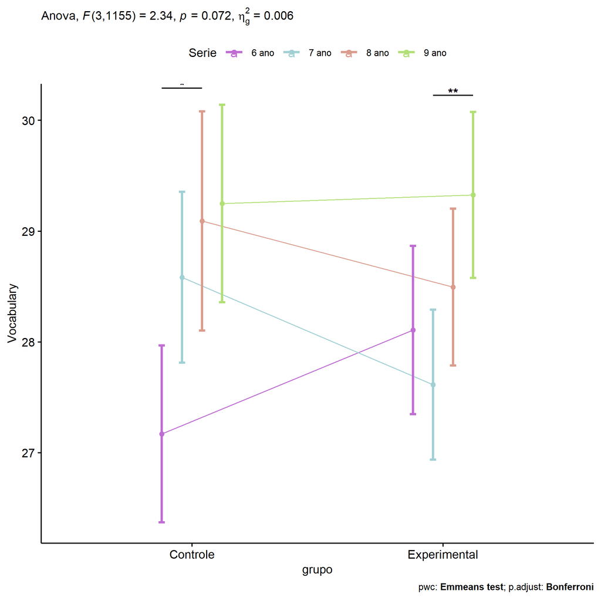

```r
if (length(unique(pdat[["Serie"]])) >= 2) {
  ggPlotAoC2(pwcs, "grupo", "Serie", aov, ylab = "Vocabulary",
             subtitle = which(aov$Effect == "grupo:Serie"), addParam = "errorbar") +
    ggplot2::scale_color_manual(values = color[["Serie"]]) +
    if (ymin.ci < ymax.ci) ggplot2::ylim(ymin.ci, ymax.ci)
}
```

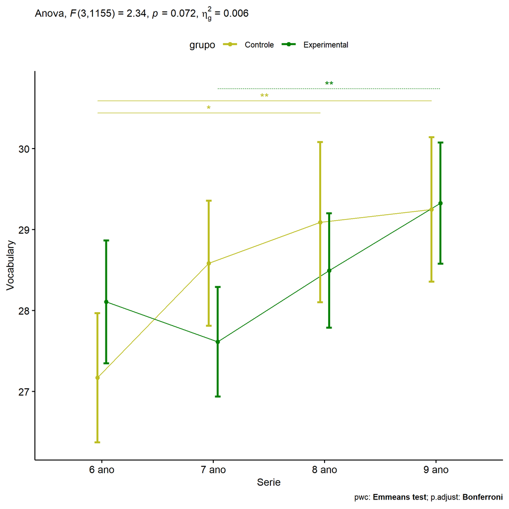

```r
if (length(unique(pdat[["Serie"]])) >= 2) {
  ggPlotAoC2(pwcs, "Serie", "grupo", aov, ylab = "Vocabulary",
               subtitle = which(aov$Effect == "grupo:Serie"), addParam = "errorbar") +
      ggplot2::scale_color_manual(values = color[["grupo"]]) +
      if (ymin.ci < ymax.ci) ggplot2::ylim(ymin.ci, ymax.ci)
}
```

```r
if (length(unique(pdat[["Serie"]])) >= 2) {
  plots <- twoWayAncovaBoxPlots(
    wdat, "vocab.pos", c("grupo","Serie"), aov, pwcs, covar = "vocab.pre",
    theme = "classic", color = color[["grupo:Serie"]],
    subtitle = which(aov$Effect == "grupo:Serie"))
}
```

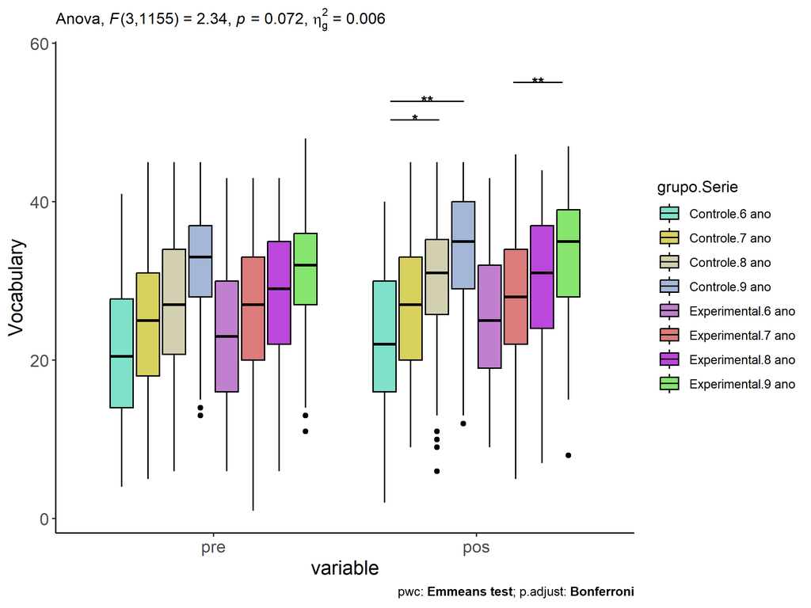

```r
if (length(unique(pdat[["Serie"]])) >= 2) {
  plots[["grupo:Serie"]] + ggplot2::ylab("Vocabulary") +
  ggplot2::scale_x_discrete(labels=c('pre', 'pos')) +
  if (ymin < ymax) ggplot2::ylim(ymin, ymax)
}
```

```r
if (length(unique(pdat[["Serie"]])) >= 2) {
  plots <- twoWayAncovaBoxPlots(
    wdat.long, "vocab", c("grupo","Serie"), aov, pwc.long,
    pre.post = "time",
    theme = "classic", color = color$prepost)
}
```

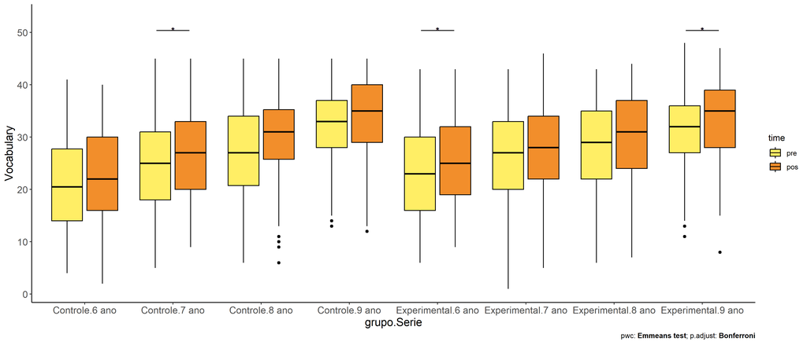

```r
if (length(unique(pdat[["Serie"]])) >= 2)
  plots[["grupo:Serie"]] + ggplot2::ylab("Vocabulary") +
    if (ymin < ymax) ggplot2::ylim(ymin, ymax)
```

### Checking linearity assumption

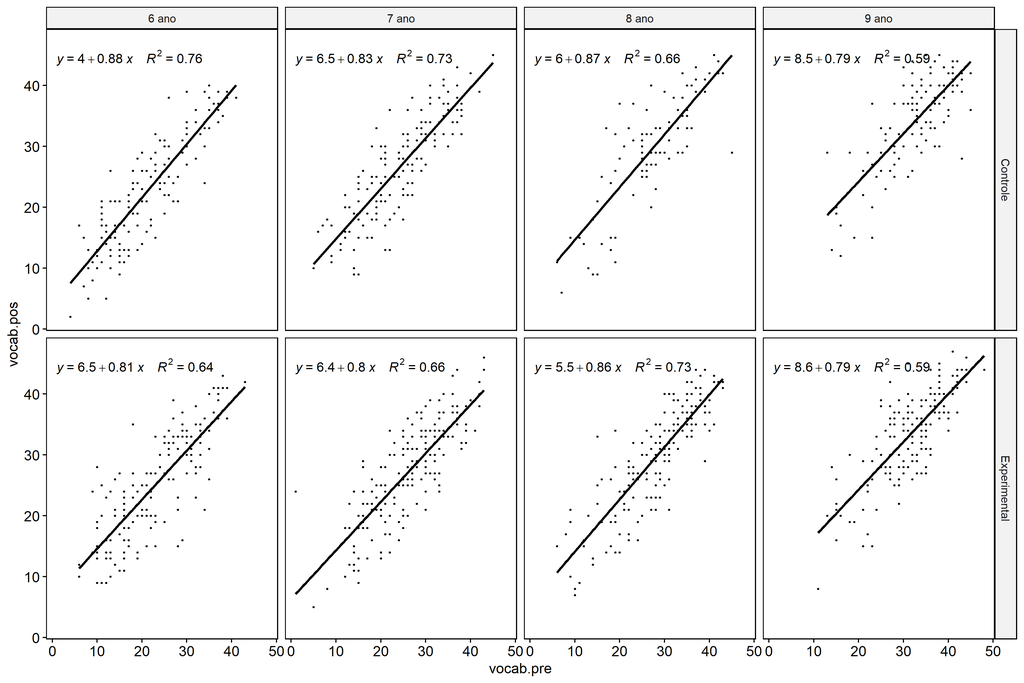

```r
if (length(unique(pdat[["Serie"]])) >= 2) {
  ggscatter(wdat, x = "vocab.pre", y = "vocab.pos", size = 0.5,
            facet.by = c("grupo","Serie"), add = "reg.line")+
    stat_regline_equation(
      aes(label =  paste(..eq.label.., ..rr.label.., sep = "~~~~"))
    ) +
    if (ymin < ymax) ggplot2::ylim(ymin, ymax)
}
```

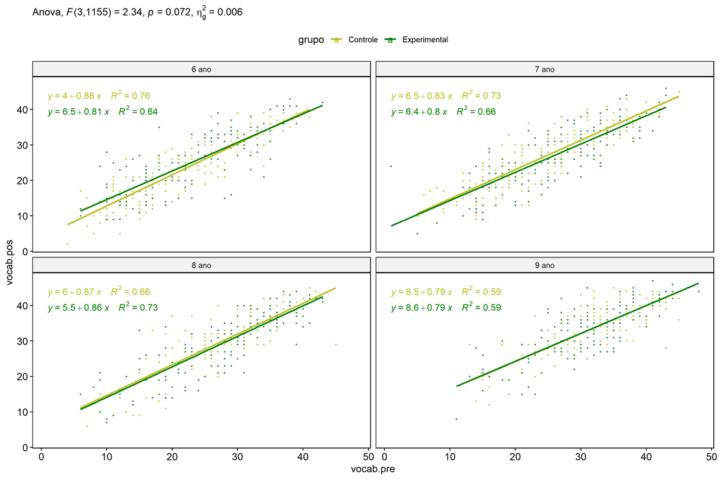

```r
if (length(unique(pdat[["Serie"]])) >= 2) {
  ggscatter(wdat, x = "vocab.pre", y = "vocab.pos", size = 0.5,
            color = "grupo", facet.by = "Serie", add = "reg.line")+
    stat_regline_equation(
      aes(label =  paste(..eq.label.., ..rr.label.., sep = "~~~~"), color = grupo)
    ) +
    ggplot2::labs(subtitle = rstatix::get_test_label(aov, detailed = T, row = which(aov$Effect == "grupo:Serie"))) +
    ggplot2::scale_color_manual(values = color[["grupo"]]) +
    if (ymin < ymax) ggplot2::ylim(ymin, ymax)
}
```

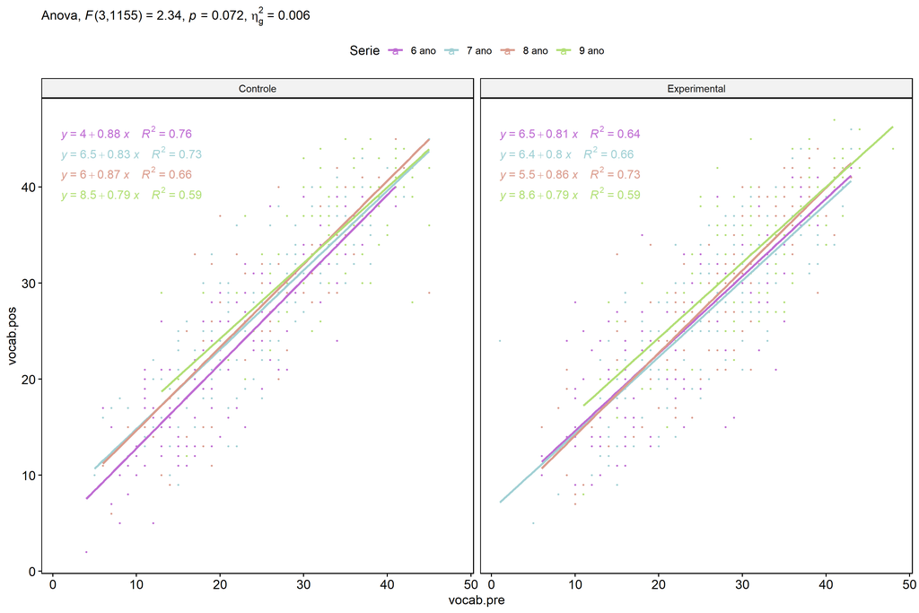

```r
if (length(unique(pdat[["Serie"]])) >= 2) {
  ggscatter(wdat, x = "vocab.pre", y = "vocab.pos", size = 0.5,
            color = "Serie", facet.by = "grupo", add = "reg.line")+
    stat_regline_equation(
      aes(label =  paste(..eq.label.., ..rr.label.., sep = "~~~~"), color = Serie)
    ) +
    ggplot2::labs(subtitle = rstatix::get_test_label(aov, detailed = T, row = which(aov$Effect == "grupo:Serie"))) +
    ggplot2::scale_color_manual(values = color[["Serie"]]) +
    if (ymin < ymax) ggplot2::ylim(ymin, ymax)
}
```

### Checking normality and homogeneity

```r
if (length(unique(pdat[["Serie"]])) >= 2)
  res <- augment(lm(vocab.pos ~ vocab.pre + grupo*Serie, data = wdat))
```

```r
if (length(unique(pdat[["Serie"]])) >= 2)
  shapiro_test(res$.resid)
```

```
## # A tibble: 1 × 3
##   variable   statistic p.value
##   <chr>          <dbl>   <dbl>
## 1 res$.resid     0.998   0.213
```

```r
if (length(unique(pdat[["Serie"]])) >= 2)
  levene_test(res, .resid ~ grupo*Serie)
```

```
## # A tibble: 1 × 4
##     df1   df2 statistic     p
##   <int> <int>     <dbl> <dbl>
## 1     7  1156     0.999 0.430
```

# ANCOVA and Pairwise for two factors **grupo:vocab.quintile**

## Without remove non-normal data

```r
pdat = remove_group_data(dat[!is.na(dat[["grupo"]]) & !is.na(dat[["vocab.quintile"]]),],
                         "vocab.pos", c("grupo","vocab.quintile"))
pdat = pdat[pdat[["vocab.quintile"]] %in% do.call(
  intersect, lapply(unique(pdat[["grupo"]]), FUN = function(x) {
    unique(pdat[["vocab.quintile"]][which(pdat[["grupo"]] == x)])
  })),]
pdat[["grupo"]] = factor(pdat[["grupo"]], level[["grupo"]])
pdat[["vocab.quintile"]] = factor(
  pdat[["vocab.quintile"]],
  level[["vocab.quintile"]][level[["vocab.quintile"]] %in% unique(pdat[["vocab.quintile"]])])

pdat.long <- rbind(pdat[,c("id","grupo","vocab.quintile")], pdat[,c("id","grupo","vocab.quintile")])
pdat.long[["time"]] <- c(rep("pre", nrow(pdat)), rep("pos", nrow(pdat)))
pdat.long[["time"]] <- factor(pdat.long[["time"]], c("pre","pos"))
pdat.long[["vocab"]] <- c(pdat[["vocab.pre"]], pdat[["vocab.pos"]])

if (length(unique(pdat[["vocab.quintile"]])) >= 2) {
  aov = anova_test(pdat, vocab.pos ~ vocab.pre + grupo*vocab.quintile)
  laov[["grupo:vocab.quintile"]] <- get_anova_table(aov)
}
```

```r
if (length(unique(pdat[["vocab.quintile"]])) >= 2) {
  pwcs <- list()
  pwcs[["vocab.quintile"]] <- emmeans_test(
    group_by(pdat, grupo), vocab.pos ~ vocab.quintile,
    covariate = vocab.pre, p.adjust.method = "bonferroni")
  pwcs[["grupo"]] <- emmeans_test(
    group_by(pdat, vocab.quintile), vocab.pos ~ grupo,
    covariate = vocab.pre, p.adjust.method = "bonferroni")

  pwc <- plyr::rbind.fill(pwcs[["grupo"]], pwcs[["vocab.quintile"]])
  pwc <- pwc[,c("grupo","vocab.quintile", colnames(pwc)[!colnames(pwc) %in% c("grupo","vocab.quintile")])]
}
```

```r
if (length(unique(pdat[["vocab.quintile"]])) >= 2) {
  pwc.long <- emmeans_test(dplyr::group_by_at(pdat.long, c("grupo","vocab.quintile")),
                           vocab ~ time,
                           p.adjust.method = "bonferroni")
  lpwc[["grupo:vocab.quintile"]] <- plyr::rbind.fill(pwc, pwc.long)
}
```

```r
if (length(unique(pdat[["vocab.quintile"]])) >= 2) {
  ds <- get.descriptives(pdat, "vocab.pos", c("grupo","vocab.quintile"), covar = "vocab.pre")
  ds <- merge(ds[ds$variable != "vocab.pre",],
              ds[ds$variable == "vocab.pre", !colnames(ds) %in% c("variable")],
              by = c("grupo","vocab.quintile"), all.x = T, suffixes = c("", ".vocab.pre"))
  ds <- merge(get_emmeans(pwcs[["grupo"]]), ds,
              by = c("grupo","vocab.quintile"), suffixes = c(".emms", ""))
  ds <- ds[,c("grupo","vocab.quintile","n","mean.vocab.pre","se.vocab.pre","mean","se",
              "emmean","se.emms","conf.low","conf.high")]

  colnames(ds) <- c("grupo","vocab.quintile", "N", paste0(c("M","SE")," (pre)"),
                    paste0(c("M","SE"), " (unadj)"),
                    paste0(c("M", "SE"), " (adj)"), "conf.low", "conf.high")

  lemms[["grupo:vocab.quintile"]] <- ds
}
```

## Computing ANCOVA and PairWise After removing non-normal data (OK)

```r
if (length(unique(pdat[["vocab.quintile"]])) >= 2) {
  wdat = pdat

  res = residuals(lm(vocab.pos ~ vocab.pre + grupo*vocab.quintile, data = wdat))
  non.normal = getNonNormal(res, wdat$id, plimit = 0.05)

  wdat = wdat[!wdat$id %in% non.normal,]

  wdat.long <- rbind(wdat[,c("id","grupo","vocab.quintile")], wdat[,c("id","grupo","vocab.quintile")])
  wdat.long[["time"]] <- c(rep("pre", nrow(wdat)), rep("pos", nrow(wdat)))
  wdat.long[["time"]] <- factor(wdat.long[["time"]], c("pre","pos"))
  wdat.long[["vocab"]] <- c(wdat[["vocab.pre"]], wdat[["vocab.pos"]])


  ldat[["grupo:vocab.quintile"]] = wdat

  (non.normal)
}
```

```
##  [1] "P1139" "P983"  "P1003" "P1113" "P2304" "P2207" "P2232" "P2192" "P1056" "P3654" "P1069"
## [12] "P852"  "P1966" "P2245" "P1129" "P1936" "P3042" "P996"  "P1006" "P3499" "P2850" "P1620"
## [23] "P3228" "P478"  "P916"  "P3265" "P3473" "P1831" "P2176" "P3260" "P976"  "P1865" "P489"
## [34] "P2135" "P863"  "P2251" "P2853" "P2856" "P2219" "P2458" "P887"  "P1961" "P2861" "P1952"
## [45] "P2400" "P3660" "P3259" "P606"  "P3159" "P2004" "P933"  "P1151" "P837"  "P2957" "P888"
## [56] "P2887" "P1790" "P3106" "P3038" "P2394" "P2092" "P491"  "P2866" "P2958" "P2098" "P1009"
## [67] "P1029" "P856"  "P913"  "P2348" "P985"  "P3145" "P850"
```

```r
if (length(unique(pdat[["vocab.quintile"]])) >= 2) {
  aov = anova_test(wdat, vocab.pos ~ vocab.pre + grupo*vocab.quintile)
  laov[["grupo:vocab.quintile"]] <- merge(get_anova_table(aov), laov[["grupo:vocab.quintile"]],
                                         by="Effect", suffixes = c("","'"))
  df = get_anova_table(aov)
}
```

| Effect | DFn | DFd | F | p | p<.05 | ges |
| --- | --- | --- | --- | --- | --- | --- |
| vocab.pre | 1 | 1146 | 113.416 | 0.000 | * | 0.090 |
| grupo | 1 | 1146 | 0.121 | 0.728 |  | 0.000 |
| vocab.quintile | 4 | 1146 | 3.114 | 0.015 | * | 0.011 |
| grupo:vocab.quintile | 4 | 1146 | 5.742 | 0.000 | * | 0.020 |

```r
if (length(unique(pdat[["vocab.quintile"]])) >= 2) {
  pwcs <- list()
  pwcs[["vocab.quintile"]] <- emmeans_test(
    group_by(wdat, grupo), vocab.pos ~ vocab.quintile,
    covariate = vocab.pre, p.adjust.method = "bonferroni")
  pwcs[["grupo"]] <- emmeans_test(
    group_by(wdat, vocab.quintile), vocab.pos ~ grupo,
    covariate = vocab.pre, p.adjust.method = "bonferroni")

  pwc <- plyr::rbind.fill(pwcs[["grupo"]], pwcs[["vocab.quintile"]])
  pwc <- pwc[,c("grupo","vocab.quintile", colnames(pwc)[!colnames(pwc) %in% c("grupo","vocab.quintile")])]
}
```

| grupo | vocab.quintile | term | .y. | group1 | group2 | df | statistic | p | p.adj | p.adj.signif |
| --- | --- | --- | --- | --- | --- | --- | --- | --- | --- | --- |
|  | 1st quintile | vocab.pre*grupo | vocab.pos | Controle | Experimental | 1146 | -2.811 | 0.005 | 0.005 | ** |
|  | 2nd quintile | vocab.pre*grupo | vocab.pos | Controle | Experimental | 1146 | 2.024 | 0.043 | 0.043 | * |
|  | 3rd quintile | vocab.pre*grupo | vocab.pos | Controle | Experimental | 1146 | -0.805 | 0.421 | 0.421 | ns |
|  | 4th quintile | vocab.pre*grupo | vocab.pos | Controle | Experimental | 1146 | 3.162 | 0.002 | 0.002 | ** |
|  | 5th quintile | vocab.pre*grupo | vocab.pos | Controle | Experimental | 1146 | -0.663 | 0.508 | 0.508 | ns |
| Controle |  | vocab.pre*vocab.quintile | vocab.pos | 1st quintile | 2nd quintile | 1146 | -2.829 | 0.005 | 0.047 | * |
| Controle |  | vocab.pre*vocab.quintile | vocab.pos | 1st quintile | 3rd quintile | 1146 | -3.270 | 0.001 | 0.011 | * |
| Controle |  | vocab.pre*vocab.quintile | vocab.pos | 1st quintile | 4th quintile | 1146 | -3.932 | 0.000 | 0.001 | *** |
| Controle |  | vocab.pre*vocab.quintile | vocab.pos | 1st quintile | 5th quintile | 1146 | -2.969 | 0.003 | 0.031 | * |
| Controle |  | vocab.pre*vocab.quintile | vocab.pos | 2nd quintile | 3rd quintile | 1146 | -1.462 | 0.144 | 1.000 | ns |
| Controle |  | vocab.pre*vocab.quintile | vocab.pos | 2nd quintile | 4th quintile | 1146 | -3.034 | 0.002 | 0.025 | * |
| Controle |  | vocab.pre*vocab.quintile | vocab.pos | 2nd quintile | 5th quintile | 1146 | -2.098 | 0.036 | 0.361 | ns |
| Controle |  | vocab.pre*vocab.quintile | vocab.pos | 3rd quintile | 4th quintile | 1146 | -2.781 | 0.006 | 0.055 | ns |
| Controle |  | vocab.pre*vocab.quintile | vocab.pos | 3rd quintile | 5th quintile | 1146 | -1.736 | 0.083 | 0.828 | ns |
| Controle |  | vocab.pre*vocab.quintile | vocab.pos | 4th quintile | 5th quintile | 1146 | 0.502 | 0.616 | 1.000 | ns |
| Experimental |  | vocab.pre*vocab.quintile | vocab.pos | 1st quintile | 2nd quintile | 1146 | 1.170 | 0.242 | 1.000 | ns |
| Experimental |  | vocab.pre*vocab.quintile | vocab.pos | 1st quintile | 3rd quintile | 1146 | -2.037 | 0.042 | 0.419 | ns |
| Experimental |  | vocab.pre*vocab.quintile | vocab.pos | 1st quintile | 4th quintile | 1146 | -1.339 | 0.181 | 1.000 | ns |
| Experimental |  | vocab.pre*vocab.quintile | vocab.pos | 1st quintile | 5th quintile | 1146 | -2.210 | 0.027 | 0.273 | ns |
| Experimental |  | vocab.pre*vocab.quintile | vocab.pos | 2nd quintile | 3rd quintile | 1146 | -4.264 | 0.000 | 0.000 | *** |
| Experimental |  | vocab.pre*vocab.quintile | vocab.pos | 2nd quintile | 4th quintile | 1146 | -2.840 | 0.005 | 0.046 | * |
| Experimental |  | vocab.pre*vocab.quintile | vocab.pos | 2nd quintile | 5th quintile | 1146 | -3.624 | 0.000 | 0.003 | ** |
| Experimental |  | vocab.pre*vocab.quintile | vocab.pos | 3rd quintile | 4th quintile | 1146 | 0.474 | 0.636 | 1.000 | ns |
| Experimental |  | vocab.pre*vocab.quintile | vocab.pos | 3rd quintile | 5th quintile | 1146 | -1.823 | 0.069 | 0.686 | ns |
| Experimental |  | vocab.pre*vocab.quintile | vocab.pos | 4th quintile | 5th quintile | 1146 | -2.954 | 0.003 | 0.032 | * |

```r
if (length(unique(pdat[["vocab.quintile"]])) >= 2) {
  pwc.long <- emmeans_test(dplyr::group_by_at(wdat.long, c("grupo","vocab.quintile")),
                           vocab ~ time,
                           p.adjust.method = "bonferroni")
  lpwc[["grupo:vocab.quintile"]] <- merge(plyr::rbind.fill(pwc, pwc.long),
                                         lpwc[["grupo:vocab.quintile"]],
                                         by=c("grupo","vocab.quintile","term",".y.","group1","group2"),
                                         suffixes = c("","'"))
}
```

| grupo | vocab.quintile | term | .y. | group1 | group2 | df | statistic | p | p.adj | p.adj.signif |
| --- | --- | --- | --- | --- | --- | --- | --- | --- | --- | --- |
| Controle | 1st quintile | time | vocab | pre | pos | 2294 | -5.292 | 0.000 | 0.000 | **** |
| Controle | 2nd quintile | time | vocab | pre | pos | 2294 | -4.930 | 0.000 | 0.000 | **** |
| Controle | 3rd quintile | time | vocab | pre | pos | 2294 | -4.051 | 0.000 | 0.000 | **** |
| Controle | 4th quintile | time | vocab | pre | pos | 2294 | -3.715 | 0.000 | 0.000 | *** |
| Controle | 5th quintile | time | vocab | pre | pos | 2294 | 0.373 | 0.709 | 0.709 | ns |
| Experimental | 1st quintile | time | vocab | pre | pos | 2294 | -8.343 | 0.000 | 0.000 | **** |
| Experimental | 2nd quintile | time | vocab | pre | pos | 2294 | -2.480 | 0.013 | 0.013 | * |
| Experimental | 3rd quintile | time | vocab | pre | pos | 2294 | -5.701 | 0.000 | 0.000 | **** |
| Experimental | 4th quintile | time | vocab | pre | pos | 2294 | -0.622 | 0.534 | 0.534 | ns |
| Experimental | 5th quintile | time | vocab | pre | pos | 2294 | -0.449 | 0.653 | 0.653 | ns |

```r
if (length(unique(pdat[["vocab.quintile"]])) >= 2) {
  ds <- get.descriptives(wdat, "vocab.pos", c("grupo","vocab.quintile"), covar = "vocab.pre")
  ds <- merge(ds[ds$variable != "vocab.pre",],
              ds[ds$variable == "vocab.pre", !colnames(ds) %in% c("variable")],
              by = c("grupo","vocab.quintile"), all.x = T, suffixes = c("", ".vocab.pre"))
  ds <- merge(get_emmeans(pwcs[["grupo"]]), ds,
              by = c("grupo","vocab.quintile"), suffixes = c(".emms", ""))
  ds <- ds[,c("grupo","vocab.quintile","n","mean.vocab.pre","se.vocab.pre",
              "mean","se","emmean","se.emms","conf.low","conf.high")]

  colnames(ds) <- c("grupo","vocab.quintile", "N", paste0(c("M","SE")," (pre)"),
                    paste0(c("M","SE"), " (unadj)"),
                    paste0(c("M", "SE"), " (adj)"), "conf.low", "conf.high")

  lemms[["grupo:vocab.quintile"]] <- merge(ds, lemms[["grupo:vocab.quintile"]],
                                          by=c("grupo","vocab.quintile"), suffixes = c("","'"))
}
```

| grupo | vocab.quintile | N | M (pre) | SE (pre) | M (unadj) | SE (unadj) | M (adj) | SE (adj) | conf.low | conf.high |
| --- | --- | --- | --- | --- | --- | --- | --- | --- | --- | --- |
| Controle | 1st quintile | 98 | 12.357 | 0.301 | 15.224 | 0.505 | 24.961 | 1.029 | 22.942 | 26.981 |
| Controle | 2nd quintile | 81 | 19.469 | 0.180 | 22.407 | 0.672 | 27.326 | 0.695 | 25.961 | 28.691 |
| Controle | 3rd quintile | 119 | 25.992 | 0.174 | 27.983 | 0.428 | 28.483 | 0.432 | 27.636 | 29.330 |
| Controle | 4th quintile | 89 | 32.225 | 0.156 | 34.337 | 0.453 | 30.614 | 0.607 | 29.424 | 31.805 |
| Controle | 5th quintile | 100 | 38.180 | 0.270 | 37.980 | 0.420 | 30.223 | 0.866 | 28.524 | 31.921 |
| Experimental | 1st quintile | 98 | 13.071 | 0.279 | 17.592 | 0.612 | 26.845 | 0.989 | 24.904 | 28.785 |
| Experimental | 2nd quintile | 100 | 20.060 | 0.170 | 21.390 | 0.489 | 25.908 | 0.632 | 24.669 | 27.148 |
| Experimental | 3rd quintile | 166 | 26.211 | 0.154 | 28.584 | 0.409 | 28.936 | 0.365 | 28.220 | 29.651 |
| Experimental | 4th quintile | 151 | 31.795 | 0.114 | 32.066 | 0.389 | 28.635 | 0.499 | 27.656 | 29.614 |
| Experimental | 5th quintile | 155 | 38.194 | 0.208 | 38.387 | 0.315 | 30.621 | 0.820 | 29.011 | 32.230 |